# Aggregated Code and Analyses for Heterogeneity Paper

Niall Bolger, Katherine S. Zee, Maya Rossignac-Milon, & Ran R. Hassin

# Loading Packages

```r
library(lme4)
```

```r
library(ggplot2)
library(ggthemes)
library(lmerTest)
library(car)
library(broom)
library(gridExtra)
library(ellipse)
library(dplyr)
library(brms) # note: issues with brms package on Windows 10
# Plot settings
theme_set(theme_bw(base_size = 14))


# Define function to take the sum or mean and remove NAs
sum.na <- function (x) {
  out <- sum(x, na.rm=T)
  out
}


mean.na <- function (x) {
  out <- mean(x, na.rm=T)
  out
}



# cache chunks
knitr::opts_chunk$set(cache = T)
```

# Valence RT Dataset

## Loading Data

```r
#setwd("~/Downloads/helpwithcheckingupdatestoheterogeneitycode")

rndt <- read.csv("heterogeneity_dataset1_traitvalence.csv")
```

## Valence RT: Data Subsetting

```r
rndt_sr <- subset(rndt, response.keys == "up") # subset to only select traits endorsed as self-relevant



rndt_sr$rt.z <- scale(rndt_sr$rt) #Create z-scores for RT
length((unique(rndt_sr$id))) # 62
```

```
## [1] 62
```

```r
rndt_srz <- subset(rndt_sr,  rt.z < 3) #within +3 SD of the mean RT

# New dataset without the three participants who did not select any negative words
rndtz <- rndt_srz[!(rndt_srz$id %in% c(250, 257, 272)), ]

length((unique(rndtz$id))) # 59 in final sample
```

```
## [1] 59
```

```r
#write.csv(rndtz, "heterogeneity_dataset1_traitvalence_spss.csv", row.names = F) #Version to read into SPSS
```

## Valence RT Analyses

```r
# lmer logrt - f(valence) with random intercepts only
valrt_intonly <- lmer(logrt ~ valenceE + (1 | id),  data=rndtz)
summary(valrt_intonly)
```

```
## Linear mixed model fit by REML t-tests use Satterthwaite approximations
##   to degrees of freedom [lmerMod]
## Formula: logrt ~ valenceE + (1 | id)
##    Data: rndtz
##
## REML criterion at convergence: 222.8
##
## Scaled residuals:
##     Min      1Q  Median      3Q     Max
## -3.8455 -0.6897 -0.1177  0.5756  3.2662
##
## Random effects:
##  Groups   Name        Variance Std.Dev.
##  id       (Intercept) 0.02589  0.1609
##  Residual             0.06199  0.2490
## Number of obs: 1317, groups:  id, 59
##
## Fixed effects:
##               Estimate Std. Error         df t value Pr(>|t|)
## (Intercept)    6.85701    0.02215   58.40000   309.5   <2e-16 ***
## valenceE      -0.15403    0.01495 1285.10000   -10.3   <2e-16 ***
## ---
## Signif. codes:  0 '***' 0.001 '**' 0.01 '*' 0.05 '.' 0.1 ' ' 1
##
## Correlation of Fixed Effects:
##          (Intr)
## valenceE -0.087
```

```r
# with Random Slopes
# Used in Paper
valrt_intslope <- lmer(logrt ~ valenceE + (1 + valenceE| id),  data=rndtz)
summary(valrt_intslope)
```

```
## Linear mixed model fit by REML t-tests use Satterthwaite approximations
##   to degrees of freedom [lmerMod]
## Formula: logrt ~ valenceE + (1 + valenceE | id)
##    Data: rndtz
##
## REML criterion at convergence: 202.1
##
## Scaled residuals:
##     Min      1Q  Median      3Q     Max
## -3.8004 -0.6695 -0.1272  0.5416  3.3650
##
## Random effects:
##  Groups   Name        Variance Std.Dev. Corr
##  id       (Intercept) 0.02709  0.1646
##           valenceE    0.01564  0.1250   -0.09
##  Residual             0.05872  0.2423
## Number of obs: 1317, groups:  id, 59
##
## Fixed effects:
##             Estimate Std. Error       df t value Pr(>|t|)
## (Intercept)  6.86632    0.02267 57.23000 302.912  < 2e-16 ***
## valenceE    -0.16157    0.02217 51.25000  -7.287 1.87e-09 ***
## ---
## Signif. codes:  0 '***' 0.001 '**' 0.01 '*' 0.05 '.' 0.1 ' ' 1
##
## Correlation of Fixed Effects:
##          (Intr)
## valenceE -0.134
```

### Valence RT Model comparison

```r
### Model Comparison
anova(valrt_intonly, valrt_intslope) #Compares heterogeneity with no-heterogeneity model using LR Chi-square test
```

```
## refitting model(s) with ML (instead of REML)
```

```
## Data: rndtz
## Models:
## object: logrt ~ valenceE + (1 | id)
## ..1: logrt ~ valenceE + (1 + valenceE | id)
##        Df    AIC    BIC   logLik deviance Chisq Chi Df Pr(>Chisq)
## object  4 218.41 239.15 -105.207   210.41
## ..1     6 202.59 233.68  -95.293   190.59 19.83      2  4.943e-05 ***
## ---
## Signif. codes:  0 '***' 0.001 '**' 0.01 '*' 0.05 '.' 0.1 ' ' 1
```

### Valence RT 95% Confidence Intervals for parameter estimates

- Values from `confint()` are 95% CIs that refer to how well estimated each parameter is

```r
##### 95% CIs ####

#confint(valrt_intslope) # Uses a lot of computer resources; note that CIs are for SDs of random effects, not variances
#

# Computing profile confidence intervals ...
#                   2.5 %     97.5 %
# .sig01       0.13383762  0.2013776 # 95% CI for the random intercept
# .sig02      -0.44436025  0.2838273 # 95% CI for the intercept-slope correlation
# .sig03       0.08116775  0.1701985 # 95% CI for the random slope
# .sigma       0.23291960  0.2524141 # 95% CI for the residual
# (Intercept)  6.82127497  6.9110582 # 95% CI for fixed (average) intercept
# valenceE    -0.20595293 -0.1180547 # 95% CI for fixed (average) valence effect
```

### Valence RT 95% HETEROGENEITY Intervals

- The following intervals provide the estimated range of values for the population. They indicate the range of intercept and slope effects one could expect to find if sampling from the same population.

Calculate population intervals for random intercept (level of logRT):

```r
round(6.86632  +  1.96*0.1646, digits = 2)
```

```
## [1] 7.19
```

```r
round(6.86632  -  1.96*0.1646, digits = 2)
```

```
## [1] 6.54
```

Calculate population intervals for random valence slope (heterogeneity)

```r
round(-0.16157 + 1.96*0.1250, digits = 2)
```

```
## [1] 0.08
```

```r
round(-0.16157 - 1.96*0.1250, digits = 2)
```

```
## [1] -0.41
```

## Valence RT Density Plot

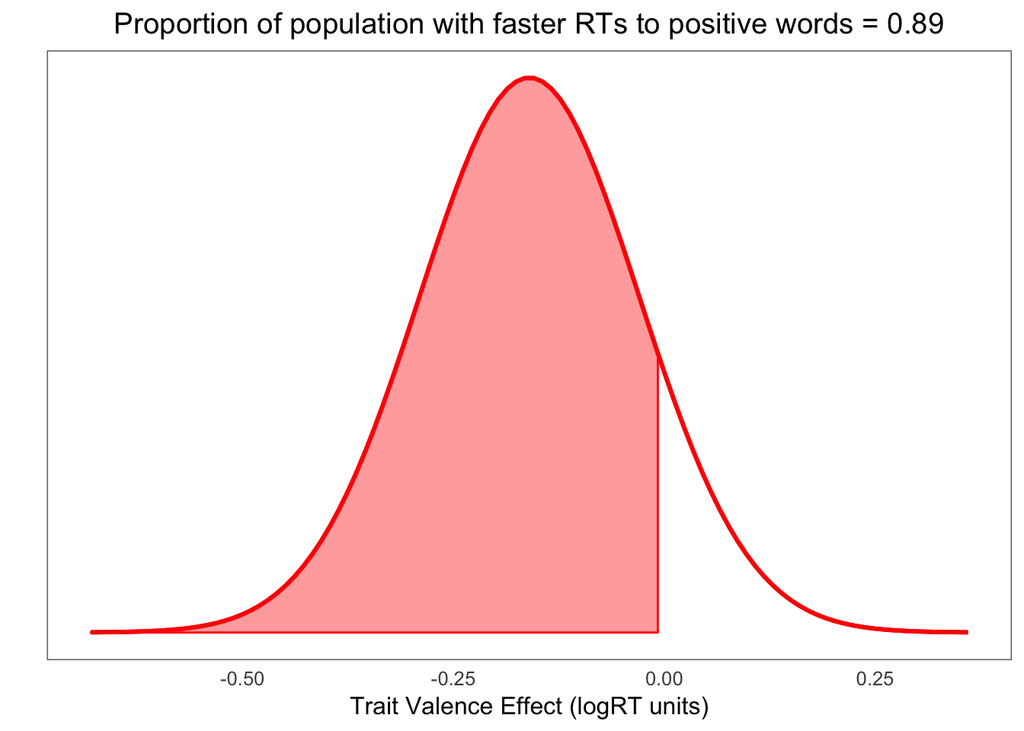

```r
### Define values needed for density plot ###

mean <- -.16 # Estimated valence slope for the average person (fixed effect)
sd <- .13 # Estimated heterogeneity (in SD units) (random effect)
ub <- 0
lb <- -1

# create an interval ranging from -4 to 4 and multiply by SD.
# This gives values falling within +/- 4SD. Then add mean.
x <- seq(-4,4,length=100)*sd + mean

# put the above into a dataframe along with the density and lower and upper bounds
# set ub (upper bound) to 0 so we can compute proportion of slope values under this number
dendf <- data.frame(
x =  seq(-4,4,length=100)*sd + mean,
hx = dnorm(x,mean,sd),
ub = 0, lb = -1)


# compute area under the curve with upper bound at 0
area <- pnorm(ub, mean, sd) - pnorm(lb, mean, sd)
denstitle <-  paste("Proportion of population with faster RTs to positive words =",
                signif(area, digits=2))

dendf$i <- dendf$x >= dendf$lb & dendf$x <= dendf$ub
x1 <- c(dendf$lb,dendf$x[dendf$i],dendf$ub)
x2 <- c(0,dendf$hx[dendf$i],0)

### Plot Density ###

densplot <- ggplot(dendf, aes(x=x)) +
  geom_path(data = dendf, aes(x=x, y=hx), alpha = 1, color = "firebrick3", size = 1)

densplot_dat <- ggplot_build(densplot)$data[[1]]

densplot2 <- densplot + geom_area(data = subset(densplot_dat, x < 0), aes(x=x, y=y), fill="red", alpha = .4, color = 'red') +
  theme_few() + xlab("Trait Valence Effect (logRT units)") + ylab("") +
   geom_path(data = dendf, aes(x=x, y=hx), alpha = 1, color = "red", size = 1) +
  ggtitle(denstitle ) +
    theme(text = element_text(size=12))  +
    theme(plot.title = element_text(hjust = 0.5)) +
  theme(
  axis.text.y = element_blank(),
  axis.ticks = element_blank())
densplot2
```

```r
#ggsave(densplot2, file = "Fig4_densplot2.pdf", height = 3.5, width = 7)
```

## Valence RT Analysis accounting for words endorsed

```r
# with Number of positive words endorsed:



# Compute the number of positive and negative words endorsed
# plus ratio of positive to negative

rndtz$posval <- ifelse(rndtz$valenceE == .5, 1, 0)
rndtz<- within(rndtz, {numpos = ave(posval, id, FUN = sum.na)})
rndtz$negval <- ifelse(rndtz$valenceE == -.5, 1, 0)
rndtz <- within(rndtz, {numneg = ave(negval, id, FUN = sum.na)})
rndtz$valenceprop <- rndtz$numpos/(rndtz$numpos + rndtz$numneg)
rndtz$valenceprop.c <- rndtz$valenceprop - mean(rndtz$valenceprop) ## centering proportion on mean, which is 62% of words endorsed as positive
```

Repeat main analysis using the proportion

```r
valrt_intslope_numpos <- lmer(logrt ~ valenceE*valenceprop.c + (1 + valenceE| id),  data=rndtz)
summary(valrt_intslope_numpos)
```

```
## Linear mixed model fit by REML t-tests use Satterthwaite approximations
##   to degrees of freedom [lmerMod]
## Formula: logrt ~ valenceE * valenceprop.c + (1 + valenceE | id)
##    Data: rndtz
##
## REML criterion at convergence: 180.5
##
## Scaled residuals:
##     Min      1Q  Median      3Q     Max
## -3.7226 -0.6552 -0.1274  0.5505  3.3240
##
## Random effects:
##  Groups   Name        Variance Std.Dev. Corr
##  id       (Intercept) 0.027568 0.1660
##           valenceE    0.007311 0.0855   -0.25
##  Residual             0.058551 0.2420
## Number of obs: 1317, groups:  id, 59
##
## Fixed effects:
##                        Estimate Std. Error       df t value Pr(>|t|)
## (Intercept)             6.87787    0.02297 57.64000 299.456  < 2e-16 ***
## valenceE               -0.16908    0.01880 56.43000  -8.994 1.72e-12 ***
## valenceprop.c          -0.09447    0.13683 58.79000  -0.690    0.493
## valenceE:valenceprop.c -0.63696    0.12224 76.12000  -5.211 1.56e-06 ***
## ---
## Signif. codes:  0 '***' 0.001 '**' 0.01 '*' 0.05 '.' 0.1 ' ' 1
##
## Correlation of Fixed Effects:
##             (Intr) valncE vlncp.
## valenceE    -0.225
## valencprp.c -0.005 -0.107
## vlncE:vlnc. -0.117  0.129 -0.212
```

```r
# even when accounting for proportion of words chosen that were positive vs. negative, we still see heterogeneity
ranef.valrt.numpos <- fixef(valrt_intslope_numpos)[2]  + ranef(valrt_intslope_numpos)$id[,2] #ValencE
```

## Valence RT Analysis with raw RT instead of logRT

```r
valrt_intslope_ms <- lmer(rtms ~ valenceE + (1 + valenceE| id),  data=rndtz)
summary(valrt_intslope_ms)
```

```
## Linear mixed model fit by REML t-tests use Satterthwaite approximations
##   to degrees of freedom [lmerMod]
## Formula: rtms ~ valenceE + (1 + valenceE | id)
##    Data: rndtz
##
## REML criterion at convergence: 18547.6
##
## Scaled residuals:
##     Min      1Q  Median      3Q     Max
## -2.8264 -0.6278 -0.2028  0.3947  4.1052
##
## Random effects:
##  Groups   Name        Variance Std.Dev. Corr
##  id       (Intercept) 27425    165.6
##           valenceE    20497    143.2    -0.28
##  Residual             67528    259.9
## Number of obs: 1317, groups:  id, 59
##
## Fixed effects:
##             Estimate Std. Error      df t value Pr(>|t|)
## (Intercept)  1007.96      22.99   56.88   43.85  < 2e-16 ***
## valenceE     -162.01      24.70   50.63   -6.56 2.78e-08 ***
## ---
## Signif. codes:  0 '***' 0.001 '**' 0.01 '*' 0.05 '.' 0.1 ' ' 1
##
## Correlation of Fixed Effects:
##          (Intr)
## valenceE -0.272
```

## Valence RT Dotplot

```r
# Save random effects and compute .025 and .975 percentiles
ranef.valrt <- fixef(valrt_intslope)[2]  + ranef(valrt_intslope)$id[,2] #ValencE
ranef.valrt.quant <- quantile(ranef.valrt, probs=c(.025, .975))

# convert ranefs to a dataframe
valrt_intslope_tidy <- tidy(summary(valrt_intslope)$varcor)
```

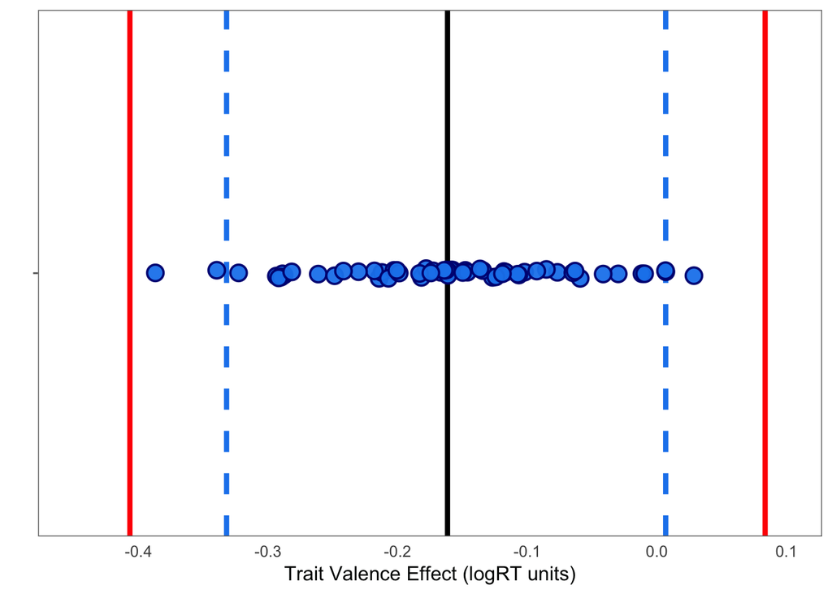

```r
ranef.valrt.pop <- c(fixef(valrt_intslope)[2] + -1.96*subset(valrt_intslope_tidy, var1 == "valenceE")$sdcor, fixef(valrt_intslope)[2] + 1.96*subset(valrt_intslope_tidy, var1 == "valenceE")$sdcor)

### Specify Dotplot ###
ranef.valrtdf <- as.data.frame(ranef.valrt)
ranef.valrtdf$x <- "x"
valrt_stripplot <- ggplot(ranef.valrtdf, aes(x=x, y=ranef.valrt)) +
  theme(legend.position="none") +
  xlab(" ") + ylab("Trait Valence Effect (logRT units)") +
  ylim(-.45, .1) +
  geom_hline(yintercept = ranef.valrt.quant[1], size = 1.5, color = "dodgerblue2", linetype="dashed") +
  geom_hline(yintercept = ranef.valrt.quant[2], size = 1.5, color = "dodgerblue2", linetype="dashed") +
  geom_hline(yintercept = summary(valrt_intslope)$coeff["valenceE", "Estimate"], size = 1.5, color = "black", linetype="solid") +
  geom_hline(yintercept = ranef.valrt.pop[1], size = 1.5, color = "red", linetype="solid") +
  geom_hline(yintercept = ranef.valrt.pop[2], size = 1.5, color = "red", linetype="solid") +
    geom_jitter(width = 0.01, height = 0, size = 4,
              shape = 21, colour = "navyblue", fill = "dodgerblue2", alpha = .95, stroke = 1) +
  theme_few() +
  theme(text = element_text(size=12))  +
  theme(axis.ticks.x = element_blank(), axis.text.y = element_blank()) + coord_flip()
valrt_stripplot
```

```r
#ggsave(valrt_stripplot, file = "valrt_stripplot.pdf", height = 2, width = 8)
```

## Valence RT Panel Plots

These plots show the raw observations and model-predicted valence effect for select participants. See Figure 2 of paper.

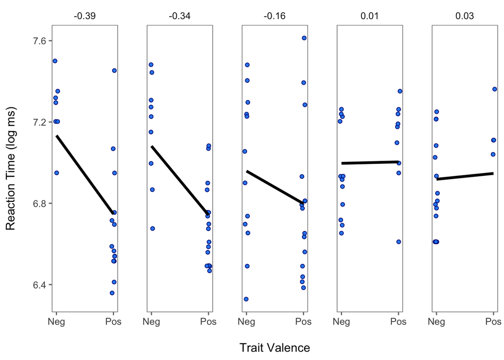

```r
#Put the EBLUPs of the random effects into a separate dataset
cfs1 <- ranef(valrt_intslope)
cfs2 <- as.data.frame(cbind(cfs1$id[,1], cfs1$id[,2]))
cfs2$id <- rbind(201,202,204,205,206,207,208,209,210,212,219,220,221,222,223,224,226,228,229,232,
           234,235,236,237,238,239,240,241,242,243,244,245,246,247,248,249,251,252,254,255,
           256,262,263,264,265,266,267,268,269,270,271,273,274,301,302,303,304,305,306) #Add in id numbers

names(cfs2) <- make.names(names(cfs2))
names(cfs2)[c(2,1)] <- c("ebslope","ebintercept")


# adding in fixed effects
cfs2$intercept<- summary(valrt_intslope)$coeff["(Intercept)", "Estimate"] + cfs2$ebintercept
cfs2$slope<- summary(valrt_intslope)$coeff["valenceE", "Estimate"] + cfs2$ebslope

#Merge upper-level variables with the process data frame
rndtz_merged <-merge(rndtz, cfs2, all=TRUE, by="id")

#Create predicted values based on within-subject causal model
rndtz_merged$pred<-rndtz_merged$intercept + rndtz_merged$slope*rndtz_merged$valenceE

#To create graphs based on observed data only: Sort the dataset by slope, ID, and valence
ordrndtz_merged<-rndtz_merged[order(rndtz_merged$slope, rndtz_merged$id, rndtz_merged$valenceE),]

#Sort the upper-level data frame by slope and ID
ordcfs2<-cfs2[order(cfs2$slope, cfs2$id),]





ordrndtz_merged_sub <- subset(ordrndtz_merged, id == 208 | id == 222 | id == 241 |
                                id == 207 | id == 247)
ordrndtz_merged_sub <- dplyr::select(ordrndtz_merged_sub, id, valenceE, logrt, slope, intercept)
ordrndtz_merged_sub <- mutate(ordrndtz_merged_sub,
                     id = reorder(id, slope))

ordrndtz_merged_sub2 <- dplyr::select(ordrndtz_merged_sub, id, slope)

newavg <- data.frame(valenceE = c(-5., .5))
newavg$predlogrt <- predict(valrt_intslope, re.form = NA, newavg)
newvary <- expand.grid(valenceE = c(-.5, .5), id = c(208, 222, 241, 207, 247))
newvary$logrt <- predict(valrt_intslope, newvary)
newvary <- merge(newvary, ordrndtz_merged_sub2, by = "id")
newvary <- mutate(newvary, id = reorder(id, slope))
newvary$sloperound <- round(newvary$slope, digits = 2)


ordrndtz_merged_sub$valenceEfac <- ifelse(ordrndtz_merged_sub$valenceE == .5, "Pos", "Neg")

to_string <- as_labeller(c(`208` = paste(unique(subset(newvary, id == 208)$sloperound)),
                           `207` = paste(unique(subset(newvary, id == 207)$sloperound)),
                           `222` = paste(unique(subset(newvary, id == 222)$sloperound)),
                           `241` = paste(unique(subset(newvary, id == 241)$sloperound)),
                           `247` = paste(unique(subset(newvary, id == 247)$sloperound))))


valrt_panelplot_all <- ggplot(ordrndtz_merged_sub, aes(valenceE, logrt)) +
  geom_jitter(height = 0, width = .03, size = 1.5,
              shape = 21, colour = "navyblue", fill = "dodgerblue2", alpha = .95, stroke = .5) +
   theme_few()  + geom_line(data = newvary, col = "black", size = 1.3) + ylab("Reaction Time (log ms)\n") +
  xlab("\nTrait Valence") + scale_x_continuous(breaks=seq(-.5, .5, 1),
                                             labels = paste0(c("Neg", "Pos"))) +
  theme(text = element_text(size=12))

valrt_panelplot_ids <- valrt_panelplot_all + facet_wrap(~id, labeller = to_string, nrow = 1) +
  theme(panel.spacing = unit(2, "lines"))
valrt_panelplot_ids
```

```r
#ggsave(valrt_panelplot_ids, file = "Fig2_valrt_panelplotbyranef_subIDs_180708.pdf", height = 4, width = 8)
```

## Valence RT: Raw differences vs. Model predictions

```r
rndtznum <- dplyr::select(rndtz, id, numneg)
#rndtznum[order(rndtznum$numneg),]
# need to omit 306 bc this participant only chose 1 neg trait


ids <- unique(subset(rndtz, id != 306)$id)
diff <- data.frame(sub = ids, diff = NA, lower = NA, upper = NA)
rndtz$valenceEfac <- ifelse(rndtz$valenceE == -.5, "n", "p")
for(i in ids){
  data_i <- subset(rndtz, rndtz$id == i)
  rts <- split(data_i, data_i$valenceEfac)
  t <- t.test(rts$n[, "logrt"], rts$p[, "logrt"])
  diff[i, 2:4] <- c((t$estimat[2]-t$estimat[1]), t$conf.int[2:1])
}
diff_i <- diff[order(diff$diff),]
diff_i$id <- as.numeric(row.names(diff_i))
diff_i$lower <- -1*diff_i$lower
diff_i$upper <- -1*diff_i$upper
diff_i <- subset(diff_i, is.na(diff)==F)

## Merge raw estimates with model estimates of valence effect

valranefs <- dplyr::select(cfs2, id, slope)
valestimates <- merge(diff_i, valranefs, by = 'id')
valestimates2 <- valestimates[order(valestimates$diff),]
head(valestimates2)
```

```
##     id sub       diff      lower       upper      slope
## 43 263  NA -0.6210560 -0.7718351 -0.47027702 -0.2889106
## 7  208  NA -0.5693457 -0.7820038 -0.35668757 -0.3870073
## 56 303  NA -0.5461491 -1.0784710 -0.01382727 -0.2817847
## 40 255  NA -0.4880640 -0.8431991 -0.13292901 -0.3227697
## 14 222  NA -0.4558681 -0.6756969 -0.23603922 -0.3396336
## 47 267  NA -0.4327853 -0.7507641 -0.11480661 -0.2918502
```

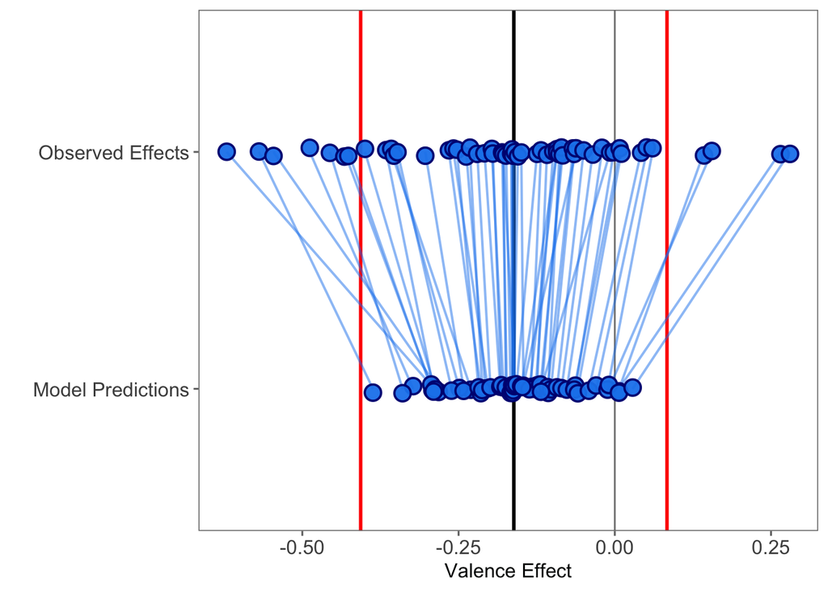

```r
valestimates2$idorder <- 1:58



###### New figure #####
valestimates_rawdiff <- dplyr::select(valestimates2, id, diff)
colnames(valestimates_rawdiff) <- c('id', 'diff_rt')
valestimates_rawdiff$type <- "Observed Effects"

valestimates_preddiff <- dplyr::select(valestimates2, id, slope)
colnames(valestimates_preddiff) <- c('id', 'diff_rt')
valestimates_preddiff$type <- "Model Predictions"

valestimates3 <- rbind(valestimates_rawdiff, valestimates_preddiff)


plotvalest2 <- ggplot(valestimates3, aes(type, diff_rt)) +
  geom_hline(yintercept = summary(valrt_intslope)$coeff["valenceE", "Estimate"] , size = 1, color = "black") +
  geom_hline(yintercept = 0, size = .5, color = "gray50", linetype = "solid") +
    geom_hline(yintercept = fixef(valrt_intslope)[2] + -1.96*subset(valrt_intslope_tidy, var1 == "valenceE")$sdcor, size = 1, color = "red") +
      geom_hline(yintercept = fixef(valrt_intslope)[2] + 1.96*subset(valrt_intslope_tidy, var1 == "valenceE")$sdcor, size = 1, color = "red") +
  geom_line(aes(group = id), color = "dodgerblue2", size = .7, alpha = .5) +
    geom_jitter(width = .02, height = 0, size = 4,
              shape = 21, colour = "navyblue", fill = "dodgerblue2", alpha = .95, stroke = 1)+
  xlab(" ") + ylab("Valence Effect") +
  theme_few()+
  theme(axis.text.x=element_text(size=12))+
  theme(axis.text.y=element_text(size=12))+
  theme(axis.title.y=element_text(size=12))+
  coord_flip()
plotvalest2
```

```r
#ggsave(plotvalest2, file = "Fig3_plotvalest2.pdf", height = 4, width = 8)
```

## Valence RT: Aggregation Approach for RM ANOVA

```r
#Read aggregated dataset
rndtz.ag <- read.csv("heterogeneity_dataset1_traitvalence_ANOVA.csv")


#Make an id factor
rndtz.ag <- within(rndtz.ag, {
  idcat <- as.factor(id)
})

#Set up effect coded contrasts
contrasts(rndtz.ag$idcat) <- contr.sum
levels(rndtz.ag$idcat)
```

```
##  [1] "201" "202" "204" "205" "206" "207" "208" "209" "210" "212" "219"
## [12] "220" "221" "222" "223" "224" "226" "228" "229" "232" "234" "235"
## [23] "236" "237" "238" "239" "240" "241" "242" "243" "244" "245" "246"
## [34] "247" "248" "249" "251" "252" "254" "255" "256" "262" "263" "264"
## [45] "265" "266" "267" "268" "269" "270" "271" "273" "274" "301" "302"
## [56] "303" "304" "305" "306"
```

```r
#Repeated measures ANOVA using aov function
valrt.rmanova <- aov(logrt ~ valenceE + idcat, data=rndtz.ag)
summary(valrt.rmanova)
```

```
##             Df Sum Sq Mean Sq F value   Pr(>F)
## valenceE     1  0.845  0.8446  46.276 6.28e-09 ***
## idcat       58  3.877  0.0668   3.662 9.49e-07 ***
## Residuals   58  1.059  0.0183
## ---
## Signif. codes:  0 '***' 0.001 '**' 0.01 '*' 0.05 '.' 0.1 ' ' 1
```

```r
coef(valrt.rmanova)
```

```
##  (Intercept)     valenceE       idcat1       idcat2       idcat3
##  6.878054007 -0.169208420 -0.098225271 -0.163966747 -0.180420725
##       idcat4       idcat5       idcat6       idcat7       idcat8
## -0.231053761  0.137957726  0.147988840  0.097496278  0.316348716
##       idcat9      idcat10      idcat11      idcat12      idcat13
## -0.262252232  0.106136049 -0.131667957 -0.079065344  0.245898089
##      idcat14      idcat15      idcat16      idcat17      idcat18
##  0.052216170 -0.236208657 -0.269615206  0.083391061 -0.099509229
##      idcat19      idcat20      idcat21      idcat22      idcat23
## -0.055030966  0.118640281  0.198839386  0.105824018 -0.127837266
##      idcat24      idcat25      idcat26      idcat27      idcat28
##  0.081433463  0.098471706  0.278992398 -0.169167406  0.001325366
##      idcat29      idcat30      idcat31      idcat32      idcat33
## -0.297000486  0.080751418 -0.202142610 -0.178430380 -0.064212933
##      idcat34      idcat35      idcat36      idcat37      idcat38
##  0.137874424 -0.051064809 -0.137024221  0.352571537 -0.152401111
##      idcat39      idcat40      idcat41      idcat42      idcat43
##  0.184002836  0.063740670 -0.067503643  0.190507668  0.320347851
##      idcat44      idcat45      idcat46      idcat47      idcat48
## -0.296750194  0.204885040  0.030238447 -0.007847869 -0.282980655
##      idcat49      idcat50      idcat51      idcat52      idcat53
##  0.055575535  0.123639558  0.141468430  0.192208976  0.053222256
##      idcat54      idcat55      idcat56      idcat57      idcat58
## -0.008590525  0.064656142  0.153697063 -0.261432703 -0.447877851
```

```r
confint(valrt.rmanova)
```

```
##                    2.5 %       97.5 %
## (Intercept)  6.853158688  6.902949325
## valenceE    -0.218999057 -0.119417782
## idcat1      -0.287822370  0.091371828
## idcat2      -0.353563846  0.025630352
## idcat3      -0.370017824  0.009176374
## idcat4      -0.420650860 -0.041456662
## idcat5      -0.051639373  0.327554826
## idcat6      -0.041608259  0.337585939
## idcat7      -0.092100821  0.287093378
## idcat8       0.126751617  0.505945815
## idcat9      -0.451849331 -0.072655132
## idcat10     -0.083461050  0.295733148
## idcat11     -0.321265056  0.057929142
## idcat12     -0.268662443  0.110531756
## idcat13      0.056300990  0.435495188
## idcat14     -0.137380929  0.241813269
## idcat15     -0.425805756 -0.046611557
## idcat16     -0.459212305 -0.080018107
## idcat17     -0.106206038  0.272988160
## idcat18     -0.289106328  0.090087870
## idcat19     -0.244628065  0.134566133
## idcat20     -0.070956818  0.308237380
## idcat21      0.009242287  0.388436485
## idcat22     -0.083773081  0.295421118
## idcat23     -0.317434365  0.061759833
## idcat24     -0.108163636  0.271030563
## idcat25     -0.091125393  0.288068806
## idcat26      0.089395299  0.468589498
## idcat27     -0.358764505  0.020429693
## idcat28     -0.188271733  0.190922466
## idcat29     -0.486597585 -0.107403387
## idcat30     -0.108845681  0.270348518
## idcat31     -0.391739709 -0.012545510
## idcat32     -0.368027479  0.011166719
## idcat33     -0.253810032  0.125384166
## idcat34     -0.051722675  0.327471524
## idcat35     -0.240661908  0.138532291
## idcat36     -0.326621320  0.052572878
## idcat37      0.162974438  0.542168637
## idcat38     -0.341998210  0.037195989
## idcat39     -0.005594263  0.373599935
## idcat40     -0.125856429  0.253337769
## idcat41     -0.257100742  0.122093456
## idcat42      0.000910569  0.380104768
## idcat43      0.130750752  0.509944951
## idcat44     -0.486347293 -0.107153094
## idcat45      0.015287941  0.394482139
## idcat46     -0.159358652  0.219835547
## idcat47     -0.197444968  0.181749231
## idcat48     -0.472577754 -0.093383555
## idcat49     -0.134021564  0.245172634
## idcat50     -0.065957541  0.313236658
## idcat51     -0.048128669  0.331065529
## idcat52      0.002611877  0.381806075
## idcat53     -0.136374843  0.242819355
## idcat54     -0.198187624  0.181006574
## idcat55     -0.124940957  0.254253242
## idcat56     -0.035900036  0.343294162
## idcat57     -0.451029802 -0.071835603
## idcat58     -0.637474950 -0.258280751
```

## Valence RT: Random Stimuli Example

```r
valrt_intslopestim <- lmer(logrt ~ valenceE + (1 + valenceE| id) + (1 | word),  data=rndtz)
summary(valrt_intslopestim)
```

```
## Linear mixed model fit by REML t-tests use Satterthwaite approximations
##   to degrees of freedom [lmerMod]
## Formula: logrt ~ valenceE + (1 + valenceE | id) + (1 | word)
##    Data: rndtz
##
## REML criterion at convergence: 145.2
##
## Scaled residuals:
##     Min      1Q  Median      3Q     Max
## -3.6995 -0.6616 -0.1187  0.5311  3.2229
##
## Random effects:
##  Groups   Name        Variance Std.Dev. Corr
##  id       (Intercept) 0.026145 0.16169
##           valenceE    0.016871 0.12989  -0.13
##  word     (Intercept) 0.005369 0.07327
##  Residual             0.053686 0.23170
## Number of obs: 1317, groups:  id, 59; word, 40
##
## Fixed effects:
##             Estimate Std. Error       df t value Pr(>|t|)
## (Intercept)  6.87519    0.02512 78.07000 273.698  < 2e-16 ***
## valenceE    -0.17330    0.03232 56.45000  -5.362 1.59e-06 ***
## ---
## Signif. codes:  0 '***' 0.001 '**' 0.01 '*' 0.05 '.' 0.1 ' ' 1
##
## Correlation of Fixed Effects:
##          (Intr)
## valenceE -0.103
```

## Valence RT: Analysis without subsetting self-relevant traits

```r
length((unique(rndt$id))) # 66, but 62 in analysis
```

```
## [1] 66
```

```r
# 4 participants (203, 211, 213, 253) contributed promotion focus scores but did not complete any experimental trials



rndt$rt.z <- scale(rndt$rt)
rndt2 <- subset(rndt, rt.z < 5)
length((unique(rndt2$id)))
```

```
## [1] 62
```

```r
# Analysis with all words included:
valrtfull_intslope <- lmer(logrt ~ valenceE + (1 + valenceE| id),  data=rndt2)
summary(valrtfull_intslope)
```

```
## Linear mixed model fit by REML t-tests use Satterthwaite approximations
##   to degrees of freedom [lmerMod]
## Formula: logrt ~ valenceE + (1 + valenceE | id)
##    Data: rndt2
##
## REML criterion at convergence: 494.1
##
## Scaled residuals:
##     Min      1Q  Median      3Q     Max
## -4.0809 -0.6912 -0.1193  0.6027  3.9388
##
## Random effects:
##  Groups   Name        Variance Std.Dev. Corr
##  id       (Intercept) 0.032093 0.17914
##           valenceE    0.008515 0.09227  -0.07
##  Residual             0.064679 0.25432
## Number of obs: 2457, groups:  id, 62
##
## Fixed effects:
##             Estimate Std. Error       df t value Pr(>|t|)
## (Intercept)  6.88355    0.02332 61.00000 295.140  < 2e-16 ***
## valenceE    -0.09040    0.01558 61.15000  -5.803 2.48e-07 ***
## ---
## Signif. codes:  0 '***' 0.001 '**' 0.01 '*' 0.05 '.' 0.1 ' ' 1
##
## Correlation of Fixed Effects:
##          (Intr)
## valenceE -0.054
```

```r
# Analysis with all words included and with moderation by endorsement:
rndt2$endorseE <- ifelse(rndt2$response.keys == "up", .5, -.5)

valrtfull_intslope_endorse <- lmer(logrt ~ valenceE*endorseE + (1 + valenceE * endorseE| id),  data=rndt2)
summary(valrtfull_intslope_endorse)
```

```
## Linear mixed model fit by REML t-tests use Satterthwaite approximations
##   to degrees of freedom [lmerMod]
## Formula: logrt ~ valenceE * endorseE + (1 + valenceE * endorseE | id)
##    Data: rndt2
##
## REML criterion at convergence: 345.2
##
## Scaled residuals:
##     Min      1Q  Median      3Q     Max
## -4.0356 -0.6741 -0.1189  0.5730  4.2342
##
## Random effects:
##  Groups   Name              Variance Std.Dev. Corr
##  id       (Intercept)       0.033022 0.18172
##           valenceE          0.003562 0.05969  -0.09
##           endorseE          0.008601 0.09274  -0.29  0.14
##           valenceE:endorseE 0.028221 0.16799  -0.11  0.37 -0.22
##  Residual                   0.058911 0.24272
## Number of obs: 2457, groups:  id, 62
##
## Fixed effects:
##                   Estimate Std. Error       df t value Pr(>|t|)
## (Intercept)        6.91347    0.02374 61.13000 291.190  < 2e-16 ***
## valenceE          -0.05986    0.01344 59.18000  -4.454 3.80e-05 ***
## endorseE          -0.08932    0.01613 58.05000  -5.537 7.76e-07 ***
## valenceE:endorseE -0.19877    0.03143 54.24000  -6.323 5.06e-08 ***
## ---
## Signif. codes:  0 '***' 0.001 '**' 0.01 '*' 0.05 '.' 0.1 ' ' 1
##
## Correlation of Fixed Effects:
##             (Intr) valncE endrsE
## valenceE    -0.039
## endorseE    -0.226 -0.133
## vlncE:ndrsE -0.134  0.064 -0.087
```

## Valence RT: Bayesian Example

Full model with random intercept and slope

```r
library(brms)
valrt_bayesian <- brm(logrt ~ valenceE + (1 + valenceE | id),  data=rndtz,
                      cores = 4, chains = 2, seed = 9)
# using default (uninformative) prior
# note: this model may take a few minutes to run
# settings for chains and cores can be adjusted to help with run time
# to change cores and chains, replace 4 and 2 in model code above
```

```r
summary(valrt_bayesian)
```

```
##  Family: gaussian
##   Links: mu = identity; sigma = identity
## Formula: logrt ~ valenceE + (1 + valenceE | id)
##    Data: rndtz (Number of observations: 1317)
## Samples: 2 chains, each with iter = 2000; warmup = 1000; thin = 1;
##          total post-warmup samples = 2000
##
## Group-Level Effects:
## ~id (Number of levels: 59)
##                         Estimate Est.Error l-95% CI u-95% CI Eff.Sample
## sd(Intercept)               0.17      0.02     0.14     0.21        442
## sd(valenceE)                0.13      0.02     0.08     0.18        755
## cor(Intercept,valenceE)    -0.09      0.19    -0.44     0.28       1152
##                         Rhat
## sd(Intercept)           1.00
## sd(valenceE)            1.00
## cor(Intercept,valenceE) 1.00
##
## Population-Level Effects:
##           Estimate Est.Error l-95% CI u-95% CI Eff.Sample Rhat
## Intercept     6.87      0.02     6.82     6.92        272 1.01
## valenceE     -0.16      0.02    -0.21    -0.12       1129 1.00
##
## Family Specific Parameters:
##       Estimate Est.Error l-95% CI u-95% CI Eff.Sample Rhat
## sigma     0.24      0.01     0.23     0.25       2000 1.00
##
## Samples were drawn using sampling(NUTS). For each parameter, Eff.Sample
## is a crude measure of effective sample size, and Rhat is the potential
## scale reduction factor on split chains (at convergence, Rhat = 1).
```

Model with random intercept only

```r
valrt_bayesianint <- brm(logrt ~ valenceE + (1 | id),  data=rndtz,
                      cores = 4, chains = 2, seed = 9)
summary(valrt_bayesianint)
```

```
##  Family: gaussian
##   Links: mu = identity; sigma = identity
## Formula: logrt ~ valenceE + (1 | id)
##    Data: rndtz (Number of observations: 1317)
## Samples: 2 chains, each with iter = 2000; warmup = 1000; thin = 1;
##          total post-warmup samples = 2000
##
## Group-Level Effects:
## ~id (Number of levels: 59)
##               Estimate Est.Error l-95% CI u-95% CI Eff.Sample Rhat
## sd(Intercept)     0.16      0.02     0.13     0.20        355 1.01
##
## Population-Level Effects:
##           Estimate Est.Error l-95% CI u-95% CI Eff.Sample Rhat
## Intercept     6.86      0.02     6.81     6.90        443 1.00
## valenceE     -0.15      0.01    -0.18    -0.13       2000 1.00
##
## Family Specific Parameters:
##       Estimate Est.Error l-95% CI u-95% CI Eff.Sample Rhat
## sigma     0.25      0.00     0.24     0.26       2000 1.00
##
## Samples were drawn using sampling(NUTS). For each parameter, Eff.Sample
## is a crude measure of effective sample size, and Rhat is the potential
## scale reduction factor on split chains (at convergence, Rhat = 1).
```

```r
set.seed(999)
WAIC(valrt_bayesian, valrt_bayesianint)
```

[output not shown]

# Face Orientation Dataset

**Dataset available from the authors upon request**

```r
##### ***Dataset available from the authors upon request *** #####
ranfacefo1 <- read.csv("heterogeneity_dataset2_faceorient.csv")
```

```r
length(unique(ranfacefo1$id))
```

```
## [1] 21
```

```r
table(ranfacefo1$id)
```

```
##
##   1   2   3   4   5   7   8   9  10  11  12  13  14  15  17  21  22  23
## 118 118 124 118 124 116 123 122 123 117 119 119 124 122 123 125 123 122
##  24  25  26
## 114 124 126
```

## Face Orientation Analysis - Full Model with Random Slope

```r
# fo = face orientation variable (-.5 = upside down, .5 = upright)

ranfacem1 <- lmer(logrt ~ fo + (fo | id), data = ranfacefo1)
summary(ranfacem1)
```

```
## Linear mixed model fit by REML t-tests use Satterthwaite approximations
##   to degrees of freedom [lmerMod]
## Formula: logrt ~ fo + (fo | id)
##    Data: ranfacefo1
##
## REML criterion at convergence: 3002.2
##
## Scaled residuals:
##     Min      1Q  Median      3Q     Max
## -2.7399 -0.6664 -0.1283  0.5832  3.7100
##
## Random effects:
##  Groups   Name        Variance Std.Dev. Corr
##  id       (Intercept) 0.08108  0.2847
##           fo          0.01167  0.1080   -0.82
##  Residual             0.18309  0.4279
## Number of obs: 2544, groups:  id, 21
##
## Fixed effects:
##             Estimate Std. Error       df t value Pr(>|t|)
## (Intercept)  5.10997    0.06271 20.00800  81.481   <2e-16 ***
## fo          -0.20156    0.02905 19.91100  -6.937    1e-06 ***
## ---
## Signif. codes:  0 '***' 0.001 '**' 0.01 '*' 0.05 '.' 0.1 ' ' 1
##
## Correlation of Fixed Effects:
##    (Intr)
## fo -0.665
```

```r
# confint(ranfacem1)
#                  2.5 %     97.5 %
# .sig01       0.20950893  0.3906011
# .sig02      -1.00000000 -0.4540153
# .sig03       0.06050036  0.1644574
# .sigma       0.41629756  0.4400204
# (Intercept)  4.98432854  5.2356294
# fo          -0.25984990 -0.1434228
```

## Face Orientation 95% HETEROGENEITY Interval

```r
#Calculate Population Heterogeneity for Intercept
round(5.11 + 1.96*0.28, digits = 2)
```

```
## [1] 5.66
```

```r
round(5.11 - 1.96*0.28, digits = 2)
```

```
## [1] 4.56
```

```r
#Calculate Population Heterogeneity for Face Orientation
round(-0.20 + 1.96*0.11, digits = 2)
```

```
## [1] 0.02
```

```r
round(-0.20 - 1.96*0.11, digits = 2)
```

```
## [1] -0.42
```

```r
#Run Model with Random Intercept Only
#in order to carry out test of random slope
```

## Face Orientation Random Intercept only Model

```r
ranfacem1_intonly <- lmer(logrt ~ fo + (1 | id), data = ranfacefo1)
summary(ranfacem1_intonly)
```

```
## Linear mixed model fit by REML t-tests use Satterthwaite approximations
##   to degrees of freedom [lmerMod]
## Formula: logrt ~ fo + (1 | id)
##    Data: ranfacefo1
##
## REML criterion at convergence: 3030.5
##
## Scaled residuals:
##     Min      1Q  Median      3Q     Max
## -2.7076 -0.6621 -0.1223  0.5833  3.5875
##
## Random effects:
##  Groups   Name        Variance Std.Dev.
##  id       (Intercept) 0.08059  0.2839
##  Residual             0.18588  0.4311
## Number of obs: 2544, groups:  id, 21
##
## Fixed effects:
##               Estimate Std. Error         df t value Pr(>|t|)
## (Intercept)    5.10927    0.06253   20.00000    81.7   <2e-16 ***
## fo            -0.20015    0.01711 2522.00000   -11.7   <2e-16 ***
## ---
## Signif. codes:  0 '***' 0.001 '**' 0.01 '*' 0.05 '.' 0.1 ' ' 1
##
## Correlation of Fixed Effects:
##    (Intr)
## fo -0.004
```

## Face Orientation Model Comparison

```r
### Model Comparison
anova(ranfacem1, ranfacem1_intonly)
```

```
## refitting model(s) with ML (instead of REML)
```

```
## Data: ranfacefo1
## Models:
## ..1: logrt ~ fo + (1 | id)
## object: logrt ~ fo + (fo | id)
##        Df    AIC    BIC  logLik deviance  Chisq Chi Df Pr(>Chisq)
## ..1     4 3028.5 3051.8 -1510.2   3020.5
## object  6 3004.6 3039.7 -1496.3   2992.6 27.858      2  8.926e-07 ***
## ---
## Signif. codes:  0 '***' 0.001 '**' 0.01 '*' 0.05 '.' 0.1 ' ' 1
```

## Face Orientation Plots

Save random effects and compute quantiles

```r
#Order by Ranef Size

ranfacem1.ranef<-ranef(ranfacem1)$id #Get Ranefs for f01
ranfacem1.ranef$id <- as.numeric(row.names(ranfacem1.ranef)) #Add ID Column

ranfacem1.ranef$fosum <- ranfacem1.ranef$fo + fixef(ranfacem1)[2]

ordranfacem1.ranef <- ranfacem1.ranef[order(ranfacem1.ranef$fosum), ]

#Add Predicted Values to ranface
ranfacefo1$pred <- fitted(ranfacem1)

#Order ranface by Participant, Face-orientation, predicted value
ordranfacefo1 <- ranfacefo1[order(ranfacefo1$id,
                            ranfacefo1$fo, ranfacefo1$pred), ]

#Calculate quantiles for dotplot
ranfacem1.quant <- as.vector(quantile(ranfacem1.ranef$fosum, probs=c(.025, .975)))

ranfacem1_tidy <- tidy(summary(ranfacem1)$varcor)
ranef.face.pop <- c(fixef(ranfacem1)[2] + -1.96*subset(ranfacem1_tidy, var1 == "fo")$sdcor, fixef(ranfacem1)[2] + 1.96*subset(ranfacem1_tidy, var1 == "fo")$sdcor)
```

## Face Orientation Dotplot

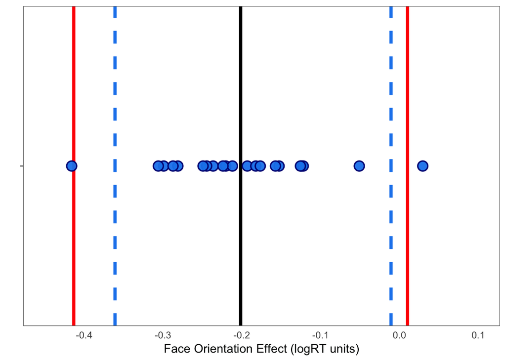

```r
ranfacem1.ranef$x <- "x"
fo_stripplot <- ggplot(ranfacem1.ranef, aes(x=x, y=fosum)) +
  theme(legend.position="none") +
  xlab(" ") + ylab("Face Orientation Effect (logRT units)") +
  ylim(-.45, .1) +
  geom_hline(yintercept = ranfacem1.quant[1], size = 1.5, color = "dodgerblue2", linetype="dashed") +
  geom_hline(yintercept = ranfacem1.quant[2], size = 1.5, color = "dodgerblue2", linetype="dashed") +
  geom_hline(yintercept = summary(ranfacem1)$coeff["fo", "Estimate"], size = 1.5, color = "black", linetype="solid") +
  geom_hline(yintercept = ranef.face.pop[1], size = 1.5, color = "red", linetype="solid") +
  geom_hline(yintercept = ranef.face.pop[2], size = 1.5, color = "red", linetype="solid") +
    geom_jitter(width = 0.0, height = 0, size = 4,
              shape = 21, colour = "navyblue", fill = "dodgerblue2", alpha = .95, stroke = 1) +
  theme_few() +
  theme(text = element_text(size=12))  +
  theme(axis.ticks.x = element_blank(), axis.text.y = element_blank()) + coord_flip()
fo_stripplot
```

```r
#ggsave(fo_stripplot, file = "Fig5_fo_stripplot.pdf", height = 2, width = 8)
```

## Face Orientation Panel Plots

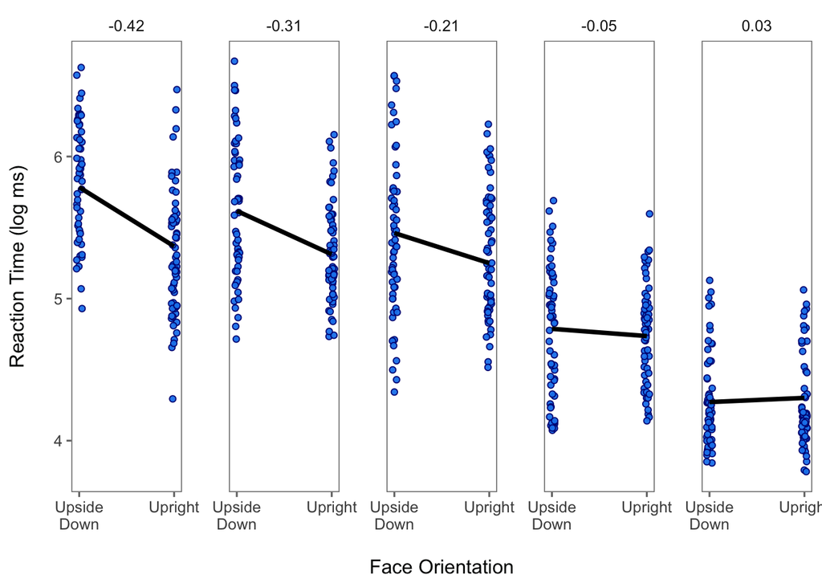

```r
foranef <- merge(ordranfacefo1, ordranfacem1.ranef, by = "id")
foranef$slope <- foranef$fosum
foranef$fo <- foranef$fo.x

foranef_sub <- subset(foranef, id == 4 | id == 11 | id == 23 |
                                id == 14 | id == 21)
foranef_sub <- dplyr::select(foranef_sub, id, fo, logrt, slope)
foranef_sub <- mutate(foranef_sub,
                              id = reorder(id, slope))

foranef_sub2 <- dplyr::select(foranef_sub, id, slope)

fo_newavg <- data.frame(fo = c(-5., .5))
fo_newavg$predlogrt <- predict(ranfacem1, re.form = NA, fo_newavg)
fo_newvary <- expand.grid(fo = c(-.5, .5), id = c(4, 11, 23, 14, 21))
fo_newvary$logrt <- predict(ranfacem1, fo_newvary)
fo_newvary <- merge(fo_newvary, foranef_sub2, by = "id")
fo_newvary <- mutate(fo_newvary, id = reorder(id, slope))
fo_newvary$sloperound <- round(fo_newvary$slope, digits = 2)


fo_to_string <- as_labeller(c(`4` = paste(unique(subset(fo_newvary, id == 4)$sloperound)),
                           `11` = paste(unique(subset(fo_newvary, id == 11)$sloperound)),
                           `23` = paste(unique(subset(fo_newvary, id == 23)$sloperound)),
                           `14` = paste(unique(subset(fo_newvary, id == 14)$sloperound)),
                           `21` = paste(unique(subset(fo_newvary, id == 21)$sloperound))))


fo_panelplot_all <- ggplot(foranef_sub, aes(fo, logrt)) +
  geom_jitter(height = 0, width = .03, size = 1.5,
              shape = 21, colour = "navyblue", fill = "dodgerblue2", alpha = .95, stroke = .5) +
  theme_few()  + geom_line(data = fo_newvary, col = "black", size = 1.3) + ylab("Reaction Time (log ms)\n") +
  xlab("\nFace Orientation") + scale_x_continuous(breaks=seq(-.5, .5, 1),
                                               labels = paste0(c("Upside\nDown", "Upright"))) +
  theme(text = element_text(size=12))

fo_panelplot_ids <- fo_panelplot_all + facet_wrap(~id, labeller = fo_to_string, nrow = 1) +
  theme(panel.spacing = unit(2, "lines"))
fo_panelplot_ids
```

```r
# ggsave(fo_panelplot_ids, file = "Fig6_ranface_panelplotbyranef_subIDs_180708.pdf", height = 4, width = 8)
```

## Face Orientation: Bayesian Example

```r
ranfacem1_bayesian <- brm(logrt ~ fo + (fo | id), data = ranfacefo1,
                          cores = 4, chains = 2, seed = 9)
summary(ranfacem1_bayesian)
```

```
##  Family: gaussian
##   Links: mu = identity; sigma = identity
## Formula: logrt ~ fo + (fo | id)
##    Data: ranfacefo1 (Number of observations: 2544)
## Samples: 2 chains, each with iter = 2000; warmup = 1000; thin = 1;
##          total post-warmup samples = 2000
##
## Group-Level Effects:
## ~id (Number of levels: 21)
##                   Estimate Est.Error l-95% CI u-95% CI Eff.Sample Rhat
## sd(Intercept)         0.30      0.06     0.22     0.43        418 1.00
## sd(fo)                0.12      0.03     0.07     0.18        711 1.00
## cor(Intercept,fo)    -0.74      0.15    -0.96    -0.36        915 1.00
##
## Population-Level Effects:
##           Estimate Est.Error l-95% CI u-95% CI Eff.Sample Rhat
## Intercept     5.11      0.07     4.97     5.25        208 1.01
## fo           -0.20      0.03    -0.27    -0.14        341 1.00
##
## Family Specific Parameters:
##       Estimate Est.Error l-95% CI u-95% CI Eff.Sample Rhat
## sigma     0.43      0.01     0.42     0.44       2000 1.00
##
## Samples were drawn using sampling(NUTS). For each parameter, Eff.Sample
## is a crude measure of effective sample size, and Rhat is the potential
## scale reduction factor on split chains (at convergence, Rhat = 1).
```

```r
# using default (uninformative) prior
# note: this model may take a few minutes to run
# settings for chains and cores can be adjusted to help with run time
```

# Math Priming (Exp 6) Dataset

```r
math <- read.csv("heterogeneity_dataset3_mathprime.csv")
```

Number of participants

```r
length(unique(math$id))
```

```
## [1] 17
```

```r
sort(table(math$id))
```

```
##
## 23 40 11 20  3  7  9  1  6 17 38 29 41 16 25 36 39
## 67 67 68 69 71 71 71 72 72 72 72 73 73 74 74 74 74
```

## Math Priming Analyses using logRT

```r
mathmod_intslope <- lmer(logrt ~ congr +  (congr | id), data = math)
summary(mathmod_intslope)
```

```
## Linear mixed model fit by REML t-tests use Satterthwaite approximations
##   to degrees of freedom [lmerMod]
## Formula: logrt ~ congr + (congr | id)
##    Data: math
##
## REML criterion at convergence: -1028.6
##
## Scaled residuals:
##      Min       1Q   Median       3Q      Max
## -10.5921  -0.6252  -0.0157   0.6220   4.0649
##
## Random effects:
##  Groups   Name        Variance  Std.Dev.  Corr
##  id       (Intercept) 2.798e-02 0.1672669
##           congr       1.761e-07 0.0004197 -1.00
##  Residual             2.338e-02 0.1528963
## Number of obs: 1214, groups:  id, 17
##
## Fixed effects:
##               Estimate Std. Error         df t value Pr(>|t|)
## (Intercept)  6.483e+00  4.081e-02  1.600e+01  158.87   <2e-16 ***
## congr       -2.230e-02  8.778e-03  1.172e+03   -2.54   0.0112 *
## ---
## Signif. codes:  0 '***' 0.001 '**' 0.01 '*' 0.05 '.' 0.1 ' ' 1
##
## Correlation of Fixed Effects:
##       (Intr)
## congr -0.011
```

## Math Priming 95% CIs for Model Parameters

```r
confint(mathmod_intslope, "congr")
```

```
## Computing profile confidence intervals ...
```

```
##             2.5 %       97.5 %
## congr -0.03951416 -0.005087118
```

```r
confint(mathmod_intslope, "(Intercept)")
```

```
## Computing profile confidence intervals ...
```

```
##                2.5 %   97.5 %
## (Intercept) 6.400443 6.564815
```

95% CI for intercept random effect

```r
confint(mathmod_intslope, ".sig01")
```

```
## Computing profile confidence intervals ...
```

```
##            2.5 %    97.5 %
## .sig01 0.1193152 0.1624786
```

95% CI for slope random effect

```r
confint(mathmod_intslope, ".sig03")
```

```
## Computing profile confidence intervals ...
```

```
##        2.5 %     97.5 %
## .sig03     0 0.02290937
```

```r
# issues with confint command
```

## Math Priming 95% HETEROGENEITY Interval

```r
#Calculate Population Heterogeneity for Intercept
round(6.48 + 1.96*.1672669, digits = 2)
```

```
## [1] 6.81
```

```r
round(6.48 - 1.96*.1672669, digits = 2)
```

```
## [1] 6.15
```

```r
#Calculate Population Heterogeneity for slope
round(-0.0223 + 1.96*0.0004197, digits = 3)
```

```
## [1] -0.021
```

```r
round(-0.0223 - 1.96*0.0004197, digits = 3)
```

```
## [1] -0.023
```

## Math Priming Random Intercept only model

```r
mathmod_int <- lmer(logrt ~ congr + (1 | id), data = math)
summary(mathmod_int)
```

```
## Linear mixed model fit by REML t-tests use Satterthwaite approximations
##   to degrees of freedom [lmerMod]
## Formula: logrt ~ congr + (1 | id)
##    Data: math
##
## REML criterion at convergence: -1028.6
##
## Scaled residuals:
##      Min       1Q   Median       3Q      Max
## -10.5900  -0.6257  -0.0162   0.6225   4.0638
##
## Random effects:
##  Groups   Name        Variance Std.Dev.
##  id       (Intercept) 0.02798  0.1673
##  Residual             0.02338  0.1529
## Number of obs: 1214, groups:  id, 17
##
## Fixed effects:
##               Estimate Std. Error         df t value Pr(>|t|)
## (Intercept)  6.483e+00  4.081e-02  1.600e+01  158.87   <2e-16 ***
## congr       -2.229e-02  8.778e-03  1.196e+03   -2.54   0.0112 *
## ---
## Signif. codes:  0 '***' 0.001 '**' 0.01 '*' 0.05 '.' 0.1 ' ' 1
##
## Correlation of Fixed Effects:
##       (Intr)
## congr 0.000
```

```r
#confint(mathmod_int, oldNames = FALSE)
```

## Math Priming Model Comparison

```r
anova(mathmod_int, mathmod_intslope)
```

```
## refitting model(s) with ML (instead of REML)
```

```
## Data: math
## Models:
## object: logrt ~ congr + (1 | id)
## ..1: logrt ~ congr + (congr | id)
##        Df     AIC     BIC logLik deviance  Chisq Chi Df Pr(>Chisq)
## object  4 -1032.8 -1012.4 520.41  -1040.8
## ..1     6 -1028.8  -998.2 520.41  -1040.8 0.0021      2     0.9989
```

## Math Priming Plots

Save random effects

```r
#Get Ranefs for congr
#Add ID Column
#Order by Ranef Size
mathmod_intslope.ranef<-ranef(mathmod_intslope)$id
mathmod_intslope.ranef$id <- as.numeric(row.names(mathmod_intslope.ranef))
mathmod_intslope.ranef$congr <- mathmod_intslope.ranef$congr + fixef(mathmod_intslope)[2]

ordmathmod_intslope.ranef <- mathmod_intslope.ranef[order(mathmod_intslope.ranef$congr), ]

#Add Predicted Values to math dataset
math$pred <- predict(mathmod_intslope)

#Order math by Participant, Predicted congruence effect, and predicted logRT
ordmath <- math[order(math$id,
                            math$congr, math$pred), ]
```

## Math Priming Dotplot

```r
mathmod.quant <- as.vector(quantile(mathmod_intslope.ranef$congr, probs=c(.025, .975)))


mathmod_intslope_tidy <- tidy(summary(mathmod_intslope)$varcor)
```

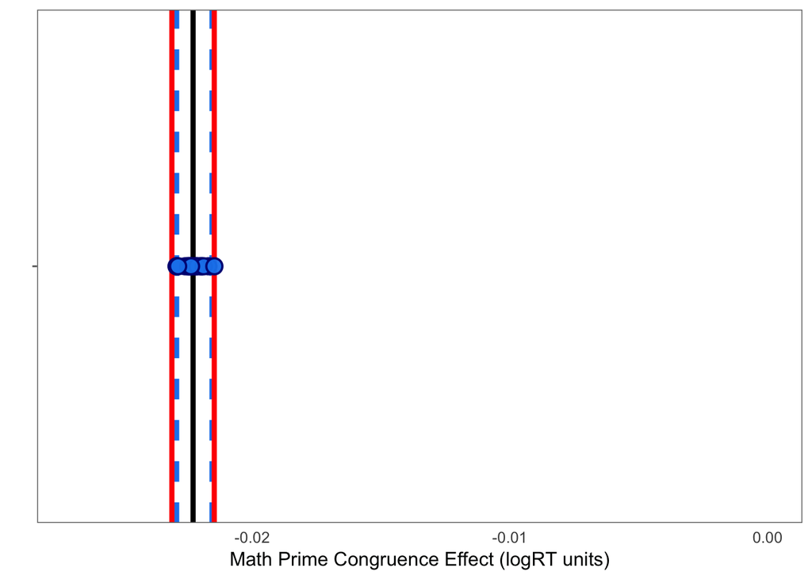

```r
ranef.math.pop <- c(fixef(mathmod_intslope)[2] + -1.96*subset(mathmod_intslope_tidy, var1 == "congr")$sdcor, fixef(mathmod_intslope)[2] + 1.96*subset(mathmod_intslope_tidy, var1 == "congr")$sdcor)




mathmod_intslope.ranef$x <- "x"
math_stripplot <- ggplot(mathmod_intslope.ranef, aes(x=x, y=congr)) +
  theme(legend.position="none") +
  xlab(" ") + ylab("Math Prime Congruence Effect (logRT units)") +
  ylim(-.027, 0) +
  geom_hline(yintercept = mathmod.quant[1], size = 1.5, color = "dodgerblue2", linetype="dashed") +
  geom_hline(yintercept = mathmod.quant[2], size = 1.5, color = "dodgerblue2", linetype="dashed") +
  geom_hline(yintercept = summary(mathmod_intslope)$coeff["congr", "Estimate"], size = 1.5, color = "black", linetype="solid") +
  geom_hline(yintercept = ranef.math.pop[1], size = 1.5, color = "red", linetype="solid") +
  geom_hline(yintercept = ranef.math.pop[2], size = 1.5, color = "red", linetype="solid") +
    geom_jitter(width = 0, height = 0, size = 4,
              shape = 21, colour = "navyblue", fill = "dodgerblue2", alpha = .95, stroke = 1) +
  theme_few() +
  theme(text = element_text(size=12))  +
  theme(axis.ticks.x = element_blank(), axis.text.y = element_blank()) + coord_flip()
math_stripplot
```

```r
#ggsave(math_stripplot, file = "Fig7_math_stripplot.pdf", height = 2, width = 8)
```

## Math Priming Panel Plots

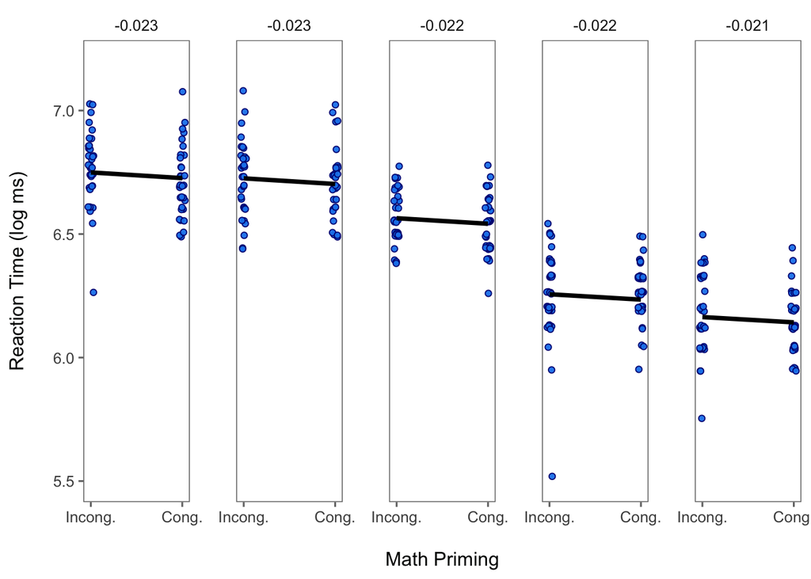

```r
# subset of participants:
#29, 41, 9,  23, 40

#mpranef <- ordmathmod_intslope.ranef
mpranef <- merge(ordmathmod_intslope.ranef, ordmath, by = "id")
mpranef$slope <- mpranef$congr.x
mpranef$congr <- mpranef$congr.y

mpranef_sub <- subset(mpranef, id == 29 | id == 41 | id == 9 |
                                id == 23 | id == 40)
mpranef_sub <- dplyr::select(mpranef_sub, id, congr, logrt, slope)
mpranef_sub <- mutate(mpranef_sub,
                              id = reorder(id, slope))

foranef_sub2 <- dplyr::select(mpranef_sub, id, slope)

mp_newavg <- data.frame(congr = c(-5., .5))
mp_newavg$predlogrt <- predict(mathmod_intslope, re.form = NA, mp_newavg)
mp_newvary <- expand.grid(congr = c(-.5, .5), id = c(29, 41, 9,  23, 40))
mp_newvary$logrt <- predict(mathmod_intslope, mp_newvary)
mp_newvary <- merge(mp_newvary, foranef_sub2, by = "id")
mp_newvary <- mutate(mp_newvary, id = reorder(id, slope))
mp_newvary$sloperound <- round(mp_newvary$slope, digits = 3)


mp_to_string <- as_labeller(c(`29` = paste(unique(subset(mp_newvary, id == 29)$sloperound)),
                           `41` = paste(unique(subset(mp_newvary, id == 41)$sloperound)),
                           `23` = paste(unique(subset(mp_newvary, id == 23)$sloperound)),
                           `9` = paste(unique(subset(mp_newvary, id == 9)$sloperound)),
                           `40` = paste(unique(subset(mp_newvary, id == 40)$sloperound))))


mp_panelplot_all <- ggplot(mpranef_sub, aes(congr, logrt)) +
  geom_jitter(height = .01, width = .03, size = 1.5,
              shape = 21, colour = "navyblue", fill = "dodgerblue2", alpha = .95, stroke = .5) +
  theme_few()  + geom_line(data = mp_newvary, col = "black", size = 1.3) + ylab("Reaction Time (log ms)\n") +
  xlab("\nMath Priming") + scale_x_continuous(breaks=seq(-.5, .5, 1),
                                               labels = paste0(c("Incong.", "Cong."))) +
  theme(text = element_text(size=12)) + ylim(5.5, 7.2)

mp_panelplot_ids <- mp_panelplot_all + facet_wrap(~id, labeller = mp_to_string, nrow = 1) +
  theme(panel.spacing = unit(2, "lines"))
mp_panelplot_ids
```

```r
#ggsave(mp_panelplot_ids, file = "Fig8_mathpriming_panelplotbyranef_subIDs_180708.pdf", height = 4, width = 8.2)
```

## Math Priming: Bayesian Example

```r
mathmod_bayesian <- brm(logrt ~ congr + (congr | id), data = math,
                        cores = 4, chains = 2, seed = 9)
print(mathmod_bayesian, digits = 4)
```

```
##  Family: gaussian
##   Links: mu = identity; sigma = identity
## Formula: logrt ~ congr + (congr | id)
##    Data: math (Number of observations: 1214)
## Samples: 2 chains, each with iter = 2000; warmup = 1000; thin = 1;
##          total post-warmup samples = 2000
##
## Group-Level Effects:
## ~id (Number of levels: 17)
##                      Estimate Est.Error l-95% CI u-95% CI Eff.Sample
## sd(Intercept)          0.1821    0.0364   0.1272   0.2697        511
## sd(congr)              0.0093    0.0074   0.0003   0.0264       1563
## cor(Intercept,congr)  -0.0150    0.5648  -0.9350   0.9515       2000
##                        Rhat
## sd(Intercept)        1.0057
## sd(congr)            1.0002
## cor(Intercept,congr) 0.9996
##
## Population-Level Effects:
##           Estimate Est.Error l-95% CI u-95% CI Eff.Sample   Rhat
## Intercept   6.4835    0.0438   6.3921   6.5657        287 1.0075
## congr      -0.0224    0.0091  -0.0400  -0.0045       2000 0.9994
##
## Family Specific Parameters:
##       Estimate Est.Error l-95% CI u-95% CI Eff.Sample   Rhat
## sigma   0.1531    0.0031   0.1469   0.1589       2000 0.9992
##
## Samples were drawn using sampling(NUTS). For each parameter, Eff.Sample
## is a crude measure of effective sample size, and Rhat is the potential
## scale reduction factor on split chains (at convergence, Rhat = 1).
```

```r
# using default (uninformative) prior
# note: this model may take a few minutes to run
# settings for chains and cores can be adjusted to help with run time
```

```r
mathmod_bayesianint <- brm(logrt ~ congr + (1 | id), data = math,
                        cores = 4, chains = 2, seed = 9)
```

Comparing model fits with random slope vs. without

```r
WAIC(mathmod_bayesianint , mathmod_bayesian)
```

```
##                                            WAIC     SE
## mathmod_bayesianint                    -1088.45 134.04
## mathmod_bayesian                       -1086.18 134.33
## mathmod_bayesianint - mathmod_bayesian    -2.26   0.47
```

The Bayesian model yields a heterogeneity (slope SD) estimate for congruence that differs from the Frequentist model estimate. This section examines the posterior distribution for the estimate.

- Visualize posterior distribution for heterogeneity of congruence effect.

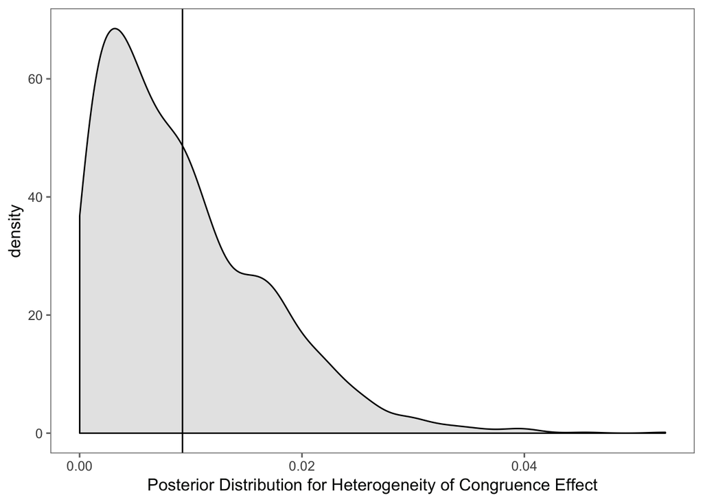

```r
p <- posterior_samples(mathmod_bayesian)
postden <- ggplot(p, aes(x = sd_id__congr)) +
  geom_density(fill = "gray", alpha = .4) + theme_few() +
  xlab("Posterior Distribution for Heterogeneity of Congruence Effect") +
  geom_vline(xintercept = mean(p$sd_id__congr))
postden
```

Because distribution is heavily skewed, compute mode value for heterogeneity of congruence effect.

```r
density(p$sd_id__congr)
```

```
##
## Call:
##  density.default(x = p$sd_id__congr)
##
## Data: p$sd_id__congr (2000 obs.);    Bandwidth 'bw' = 0.001455
##
##        x                   y
##  Min.   :-0.004356   Min.   : 0.00156
##  1st Qu.: 0.010995   1st Qu.: 0.25204
##  Median : 0.026346   Median : 3.30125
##  Mean   : 0.026346   Mean   :16.26938
##  3rd Qu.: 0.041696   3rd Qu.:26.93087
##  Max.   : 0.057047   Max.   :68.51479
```

```r
which.max(density(p$sd_id__congr)$y)
```

```
## [1] 64
```

```r
highestden <- density(p$sd_id__congr)$x[which.max(density(p$sd_id__congr)$y)]
highestden
```

```
## [1] 0.003214409
```

Assess the size of the modal heterogeneity value from the posterior relative to fixed effect.

```r
highestden / abs(fixef(mathmod_bayesian)["congr", "Estimate"])
```

```
## [1] 0.1434335
```

```r
# below the proposed 25% cutoff
```

Plot density with mode value (green line)

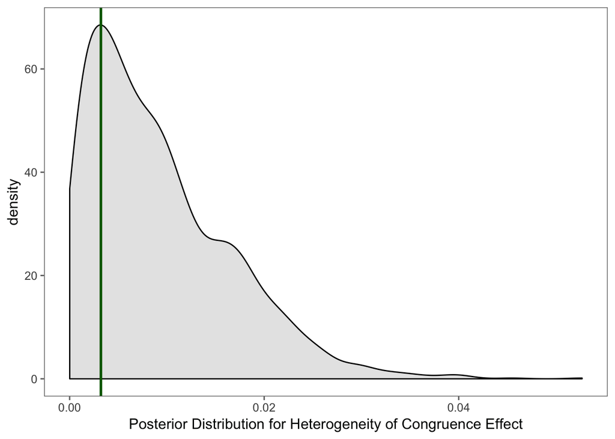

```r
postden_mode <- ggplot(p, aes(x = sd_id__congr)) +
  geom_density(fill = "gray", alpha = .4) + theme_few() +
  xlab("Posterior Distribution for Heterogeneity of Congruence Effect") +
  geom_vline(xintercept = highestden, color = "darkgreen", size = 1)
postden_mode
```

# Explaining Causal Heterogeneity - Reg Focus Analyses with Study 1 Dataset

## Dataset 1: testing for moderation of trait valence effect by Regulatory Focus

```r
# creating centered promotion

promdf <- subset(rndtz, !duplicated(id))
promdf2 <- dplyr::select(promdf, id, prom.v)
promdf2$prom.c <- scale(promdf2$prom.v, center = T, scale = F)

rndtz <- merge(rndtz, promdf2, by = "id")
sd(rndtz$prom.c)
```

```
## [1] 0.4704099
```

## Valence RT effect moderated by promotion

```r
modindiv1 <- lmer(logrt ~ valenceE*prom.c + (1 + valenceE| id),  data=rndtz)
summary(modindiv1)
```

```
## Linear mixed model fit by REML t-tests use Satterthwaite approximations
##   to degrees of freedom [lmerMod]
## Formula: logrt ~ valenceE * prom.c + (1 + valenceE | id)
##    Data: rndtz
##
## REML criterion at convergence: 195.8
##
## Scaled residuals:
##     Min      1Q  Median      3Q     Max
## -3.7554 -0.6642 -0.1187  0.5533  3.3229
##
## Random effects:
##  Groups   Name        Variance Std.Dev. Corr
##  id       (Intercept) 0.02551  0.1597
##           valenceE    0.01335  0.1155   -0.27
##  Residual             0.05860  0.2421
## Number of obs: 1317, groups:  id, 59
##
## Fixed effects:
##                 Estimate Std. Error       df t value Pr(>|t|)
## (Intercept)      6.86942    0.02211 56.19000 310.758  < 2e-16 ***
## valenceE        -0.16165    0.02131 52.13000  -7.585 5.71e-10 ***
## prom.c          -0.10031    0.04519 56.83000  -2.220  0.03044 *
## valenceE:prom.c -0.12941    0.04475 59.78000  -2.892  0.00533 **
## ---
## Signif. codes:  0 '***' 0.001 '**' 0.01 '*' 0.05 '.' 0.1 ' ' 1
##
## Correlation of Fixed Effects:
##             (Intr) valncE prom.c
## valenceE    -0.253
## prom.c       0.011 -0.061
## vlncE:prm.c -0.064  0.048 -0.198
```

```r
#confint(modindiv1)
```

## Compute Conditional Variance

```r
##### Compute Conditional Variance ######

#Get interaction coefficient
valXprom.coeff <- fixef(modindiv1)[4]

#Get residual variance of valence random effect in model with promotion
residvalvar <- VarCorr(modindiv1, comp="Variance")$id["valenceE", "valenceE"]

#Calculate the implied total valence random effect variance
#imptotalvalvar <- sd(subset(rndtz, trial==1)$prom.c)^2*valXprom.coeff^2 + valvariance # should valvariance be residvalvar?
imptotalvalvar <- valXprom.coeff^2*sd(promdf2$prom.c)^2 + residvalvar # should valvariance be residvalvar? # ^updated 181022 with better prom value
```

Variance Explained by Valence x Promotion interaction - 23% of variance explained by interaction effect

```r
## Variance Explained by Valence x Promotion interaction
1-(residvalvar/imptotalvalvar)
```

```
## valenceE:prom.c
##       0.2348552
```

```r
# 23% of variance explained by interaction effect
```

## Valence X Promotion Figures

Save random effects and compute quantiles

```r
promotionranef <- ranef(modindiv1)$id
colnames(promotionranef) <- c("intercept_prom", "slope_prom")

promotionranef$id <- as.numeric(row.names(promotionranef))

#Create dataset with one line per person with prom.c score
promotionranef <- merge(promotionranef, promdf2, by = 'id')
#Add prom.c scores to file with valence slopes for prom.c model
#promotionranef$prom.c

#rndtz_merged.prom <- merge(rndtz_merged, promotionranef, by = "id")


# Person-specific implied total valence effects for model controlling for promotion focus
ranef.prom.pred.tot <- fixef(modindiv1)[2] +
                   fixef(modindiv1)[4]*promotionranef$prom.c +
                  ranef(modindiv1)$id[,2]

#Quantile for same
ranef.prom.pred.tot.quant <- as.vector(quantile(ranef.prom.pred.tot, probs=c(.025, .975)))
ranef.prom.pred.tot.pop1 <- c(mean(ranef.prom.pred.tot) + -1.96*sd(ranef.prom.pred.tot),
                             mean(ranef.prom.pred.tot) + 1.96*sd(ranef.prom.pred.tot))
ranef.prom.pred.tot.pop <- c(mean(ranef.prom.pred.tot) + -1.96*sqrt(imptotalvalvar),
                             mean(ranef.prom.pred.tot) + 1.96*sqrt(imptotalvalvar))



# population limits for model with promotion
modindiv1_tidy <- tidy(summary(modindiv1)$varcor)
ranef.valrt.prom.pop <- c(fixef(modindiv1)[2] + -1.96*subset(modindiv1_tidy, var1 == "valenceE")$sdcor, fixef(modindiv1)[2] + 1.96*subset(modindiv1_tidy, var1 == "valenceE")$sdcor)



# Person-specific residual valence effects for model controlling for promotion focus
ranef.prom.pred.resid <- fixef(modindiv1)[2] + ranef(modindiv1)$id[,2]

#Quantile for same
ranef.prom.pred.resid.quant <- as.vector(quantile(ranef.prom.pred.resid, probs=c(.025, .975)))
```

## Strip Plots showing Effect of Promotion on Heterogeneity

Part 1

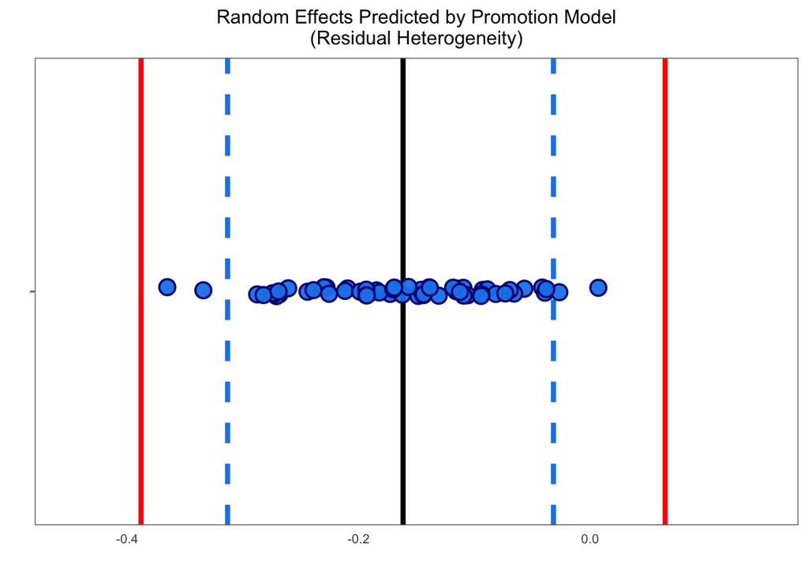

```r
### ggplot strip plot
###### New figure #####
promotionranef_noprom <- data.frame(id = row.names(ranef(modindiv1)$id), rt = (ranef.prom.pred.tot))
promotionranef_noprom$type <- "Predictions Removing Promotion Focus"


promotionranef_prom <- data.frame(id = row.names(ranef(modindiv1)$id), rt = (fixef(modindiv1)[2] + ranef(modindiv1)$id[,2]))
promotionranef_prom$type <- "Predictions with Promotion Focus"


promotion_stripplot <- ggplot(promotionranef_prom, aes(x=type, y=rt)) +
  theme(legend.position="none") +
  xlab(" ") + ylab(" ") + ggtitle("Random Effects Predicted by Promotion Model\n(Residual Heterogeneity)")+
  ylim(-.45, .15) +
  geom_hline(yintercept = ranef.prom.pred.resid.quant[1], size = 1.5, color = "dodgerblue2", linetype="dashed") +
  geom_hline(yintercept = ranef.prom.pred.resid.quant[2], size = 1.5, color = "dodgerblue2", linetype="dashed") +
    geom_hline(yintercept = ranef.valrt.prom.pop[1], size = 1.5, color = "red", linetype="solid") +
  geom_hline(yintercept = ranef.valrt.prom.pop[2], size = 1.5, color = "red", linetype="solid") +

  geom_hline(yintercept = fixef(modindiv1)[2], size = 1.5, color = "black", linetype="solid") +
    geom_jitter(width = 0.01, height = 0, size = 4,
              shape = 21, colour = "navyblue", fill = "dodgerblue2", alpha = .95, stroke = 1) +
  theme_few() +
  theme(text = element_text(size=10))  +
  theme(axis.ticks.x = element_blank(), axis.text.y = element_blank()) + coord_flip() +
    theme(plot.title = element_text(hjust = 0.5))
promotion_stripplot
```

Part 2

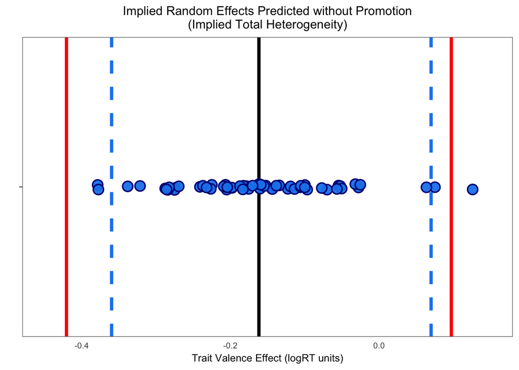

```r
nopromotion_stripplot <- ggplot(promotionranef_noprom, aes(x=type, y=rt)) +
  theme(legend.position="none") +
  xlab(" ") + ylab("Trait Valence Effect (logRT units)") +
  ggtitle("Implied Random Effects Predicted without Promotion\n(Implied Total Heterogeneity)")+
  ylim(-.45, .15) +
  geom_hline(yintercept = ranef.prom.pred.tot.quant[1], size = 1.5, color = "dodgerblue2", linetype="dashed") +
  geom_hline(yintercept = ranef.prom.pred.tot.quant[2], size = 1.5, color = "dodgerblue2", linetype="dashed") +

    geom_hline(yintercept = ranef.prom.pred.tot.pop[1], size = 1.5, color = "red", linetype="solid") +
  geom_hline(yintercept = ranef.prom.pred.tot.pop[2], size = 1.5, color = "red", linetype="solid") +

  geom_hline(yintercept = mean(ranef.prom.pred.tot), size = 1.5, color = "black", linetype="solid") +
    geom_jitter(width = 0.01, height = 0, size = 4,
              shape = 21, colour = "navyblue", fill = "dodgerblue2", alpha = .95, stroke = 1) +
  theme_few() +
  theme(text = element_text(size=10))  +
  theme(axis.ticks.x = element_blank(), axis.text.y = element_blank()) + coord_flip() +
    theme(plot.title = element_text(hjust = 0.5))
nopromotion_stripplot
```

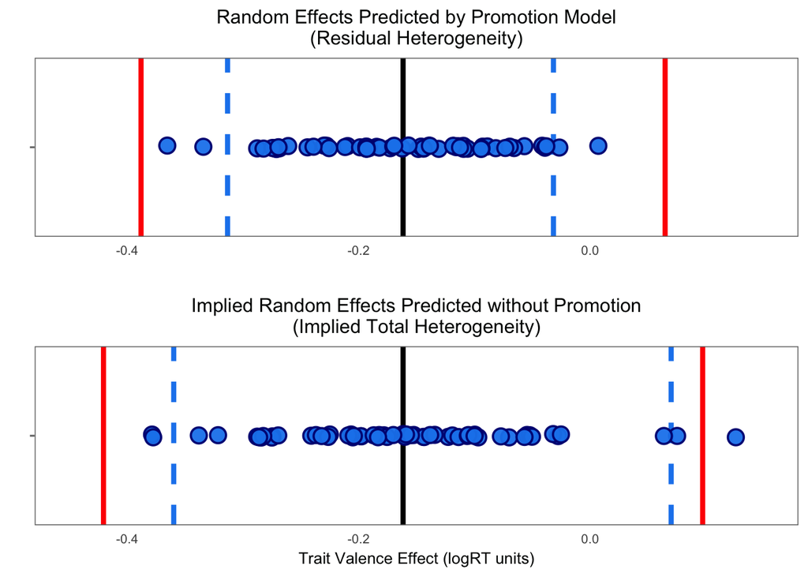

```r
promotion_stripplots <- grid.arrange(promotion_stripplot, nopromotion_stripplot, nrow = 2)
```

```r
#ggsave(promotion_stripplots, file = "Fig9_promotion_stripplots.pdf", width = 8, height = 4)
```

## Valence by Promotion Figure - Scatterplot with Distribution

Part 1

```r
##### scatterplot ######
mu_p <- c(mean(rndtz$prom.c), summary(modindiv1)$coeff["valenceE", "Estimate"])
mu_p <- as.vector(mu_p)


# implied cov
fixef(modindiv1)[4]*var(rndtz$prom.c)
```

```
##             [,1]
## [1,] -0.02863694
```

```r
sigma_pop_p <- matrix(c(var(rndtz$prom.c),
                       fixef(modindiv1)[4]*var(rndtz$prom.c),
                       fixef(modindiv1)[4]*var(rndtz$prom.c),
                       imptotalvalvar), nrow=2, byrow=TRUE)




ell_prom_pop <-as.data.frame(ellipse(sigma_pop_p, centre = mu_p, level=0.95, npoints=1000))
colnames(ell_prom_pop) <- c("a", "b")

p <- ggplot(promotionranef, aes(prom.c, ranef.prom.pred.tot)) +
   geom_hline(yintercept = 0, size = .3, color = "gray", linetype="solid") +
  geom_vline(xintercept = 0, size = .3, color = "gray", linetype="solid") +
  geom_hline(yintercept = mean(ranef.prom.pred.tot), size = .5, color = "black", linetype="solid") + stat_smooth(method = 'lm', se =F, color = "dodgerblue2", size = 1) + geom_jitter(height = 0, width = 0, size = 4,
              shape = 21, colour = "navyblue", fill = "dodgerblue2", alpha = .95, stroke = 1) +
  theme_few() + xlab("Promotion Focus (mean centered)") +
  ylab("Implied Total Heterogeneity")+
    geom_path(data=ell_prom_pop, aes(x=a, y=b), size=1, linetype="solid", color = "red") +
  ylim(-.6, .4)
  #geom_hline(yintercept = ranef.prom.pred.tot.pop[1], size = 1.5, color = "red", linetype="solid") +
  #geom_hline(yintercept = ranef.prom.pred.tot.pop[2], size = 1.5, color = "red", linetype="solid")

#ggsave(p, file = "p.pdf", height = 4, width = 6)

#ggsave(ggExtra::ggMarginal(p, type = "density"), file = "scatterhist.pdf", height = 12, width = 12)
```

Part 2

```r
##### distribution with rug #####
mean_pmodel <- fixef(modindiv1)[2] # implied fixed effect w/promotion
sd_pmodel <- subset(modindiv1_tidy, var1 == "valenceE")$sdcor # pop value

dendfprom <- data.frame(
x =  seq(-4,4,length=1000)*sd_pmodel + mean_pmodel, ub=0, lb = -1)

dendfprom$hx = dnorm(dendfprom$x, mean_pmodel, sd_pmodel)

dendfprom$i <- dendfprom$x >= dendfprom$lb & dendfprom$x <= dendfprom$ub
x1 <- c(dendfprom$lb,dendfprom$x[dendfprom$i],dendfprom$ub)
x2 <- c(0,dendfprom$hx[dendfprom$i],0)

densplotprom <- ggplot(dendfprom, aes(x=x)) +
  geom_path(data = dendfprom, aes(x=x, y=hx), alpha = 1, color = "firebrick3", size = 1) + theme_few()   +
    geom_vline(xintercept = 0, size = .3, color = "gray", linetype="solid")



densplotprom_dat <- ggplot_build(densplotprom)$data[[1]]


ranef.prom.pred.tot.df <- as.data.frame(ranef.prom.pred.tot)

densplotprom2 <- densplotprom +
  geom_area(data = subset(densplotprom_dat, x <= 0), aes(x=x, y=y), fill="red", alpha = .4, color = 'red') +
  theme_few() + xlab("Trait Valence Effect (logRT units)") + ylab("") +
   geom_path(data = dendfprom, aes(x=x, y=hx), alpha = 1, color = "red", size = 1) +
       geom_vline(xintercept = mean(ranef.prom.pred.tot), size = .5, color = "black", linetype="solid") +

 # ggtitle(denstitle ) +
  geom_rug(data = ranef.prom.pred.tot.df, aes(ranef.prom.pred.tot), color = "dodgerblue2", size = 1)+
    theme(text = element_text(size=12))  +
    theme(plot.title = element_text(hjust = 0.5)) +

    geom_vline(xintercept = ranef.prom.pred.tot.pop[1], size = 1.5, color = "red", linetype="solid") +
  geom_vline(xintercept = ranef.prom.pred.tot.pop[2], size = 1.5, color = "red", linetype="solid")+

  theme(
  axis.text.y = element_blank(),
  axis.ticks = element_blank()) +
  theme(axis.title.y=element_blank(),
        axis.text.y=element_blank(),
        axis.ticks.y=element_blank()) +
  theme(axis.title.x=element_blank(),
        axis.text.x=element_blank(),
        axis.ticks.x=element_blank()) + xlim(-.6, .4) + coord_flip()
#ggsave(densplotprom2, file = "densplotprom2.pdf", height = 5, width = 8)
# add limit lines for distribution
```

Putting Parts 1 and 2 Together

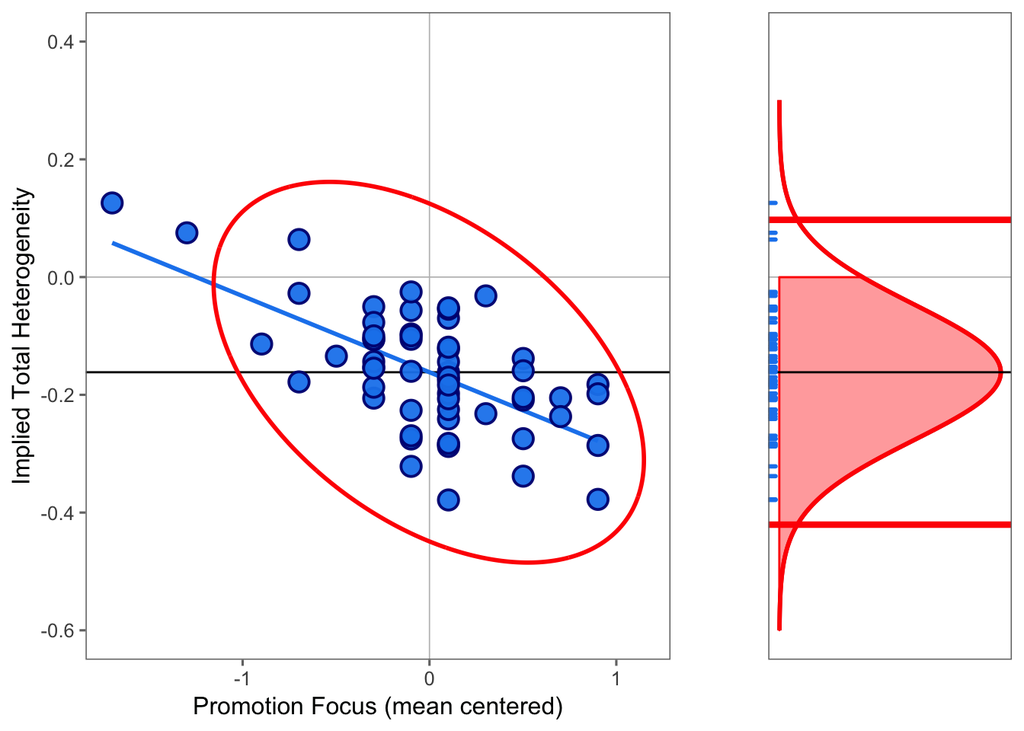

```r
#install.packages("ggpubr")
library(ggpubr)
promotion_scatter  <- ggarrange(p, densplotprom2,
          ncol = 2, nrow = 1,  align = "hv",
          widths = c(1, .5), heights = c(1, 1),
          common.legend = TRUE)
promotion_scatter
```

```r
#ggsave(promotion_scatter, file = "Fig10_promotion_scatter.pdf", height = 4, width = 8)
```

## Explaining Heterogeneity: Bayesian Example

```r
modindiv1_bayesian <- brm(logrt ~ valenceE*prom.c + (1 + valenceE| id), data=rndtz, cores = 4, chains = 2, seed = 9)
summary(modindiv1_bayesian)
```

```
##  Family: gaussian
##   Links: mu = identity; sigma = identity
## Formula: logrt ~ valenceE * prom.c + (1 + valenceE | id)
##    Data: rndtz (Number of observations: 1317)
## Samples: 2 chains, each with iter = 2000; warmup = 1000; thin = 1;
##          total post-warmup samples = 2000
##
## Group-Level Effects:
## ~id (Number of levels: 59)
##                         Estimate Est.Error l-95% CI u-95% CI Eff.Sample
## sd(Intercept)               0.16      0.02     0.13     0.20        451
## sd(valenceE)                0.12      0.02     0.07     0.17        609
## cor(Intercept,valenceE)    -0.25      0.19    -0.59     0.15       1060
##                         Rhat
## sd(Intercept)           1.00
## sd(valenceE)            1.00
## cor(Intercept,valenceE) 1.00
##
## Population-Level Effects:
##                 Estimate Est.Error l-95% CI u-95% CI Eff.Sample Rhat
## Intercept           6.87      0.02     6.82     6.91        238 1.00
## valenceE           -0.16      0.02    -0.20    -0.12        910 1.00
## prom.c             -0.10      0.05    -0.19    -0.01        285 1.01
## valenceE:prom.c    -0.13      0.05    -0.22    -0.04        814 1.00
##
## Family Specific Parameters:
##       Estimate Est.Error l-95% CI u-95% CI Eff.Sample Rhat
## sigma     0.24      0.01     0.23     0.25       2000 1.00
##
## Samples were drawn using sampling(NUTS). For each parameter, Eff.Sample
## is a crude measure of effective sample size, and Rhat is the potential
## scale reduction factor on split chains (at convergence, Rhat = 1).
```

```r
# using default (uninformative) prior
# note: this model may take a few minutes to run
# settings for chains and cores can be adjusted to help with run time
```

# Temporal Stability in Heterogeneity - Reg Focus Analyses with Scholer, Ozaki, & Higgins (JESP, 2014) Dataset

**Dataset available from the authors upon request**

```r
##### ***Dataset available from the authors upon request *** #####
RTexptboth <- read.csv("heterogeneity_dataset4_temporalstability.csv")
```

Number of participants

```r
length(unique(RTexptboth$subj))
```

```
## [1] 21
```

Number of observations per participant at each timepoint

```r
sort(table(subset(RTexptboth, t1 == 1)$subj))
```

```
##
##  3 27 17 11  4  6 12 26 16 18 19 29  5 13 20 31  7 21  1 10 24
## 12 15 16 17 19 19 19 19 20 20 21 21 22 22 22 22 23 23 26 26 26
```

```r
mean(table(subset(RTexptboth, t1 == 1)$subj))
```

```
## [1] 20.47619
```

```r
sort(table(subset(RTexptboth, t2 == 1)$subj))
```

```
##
##  3 18 29  4  6 12 17 26 27 10 11 13  7 20  1 21  5 16 19 24 31
## 11 14 16 17 18 18 18 19 19 20 20 20 21 21 22 22 24 24 24 26 26
```

```r
mean(table(subset(RTexptboth, t2 == 1)$subj))
```

```
## [1] 20
```

## Temporal Stability Model

```r
# Valence is effect coded as as -.5 = negative, +.5 = positive

logRTboth <- lmer(rt_log ~ -1 + t1 + t2
                  + t1:valenceE
                  + t2:valenceE +
                    (-1 + t1 + t2
                     + t1:valenceE
                     + t2:valenceE | subj),
                  data=RTexptboth)
summary(logRTboth)
```

```
## Linear mixed model fit by REML t-tests use Satterthwaite approximations
##   to degrees of freedom [lmerMod]
## Formula: rt_log ~ -1 + t1 + t2 + t1:valenceE + t2:valenceE + (-1 + t1 +
##     t2 + t1:valenceE + t2:valenceE | subj)
##    Data: RTexptboth
##
## REML criterion at convergence: 691.1
##
## Scaled residuals:
##     Min      1Q  Median      3Q     Max
## -2.3585 -0.6521 -0.1363  0.4600  4.2562
##
## Random effects:
##  Groups   Name        Variance Std.Dev. Corr
##  subj     t1          0.03795  0.1948
##           t2          0.04639  0.2154    0.82
##           t1:valenceE 0.03476  0.1864    0.00  0.22
##           t2:valenceE 0.07337  0.2709   -0.22 -0.10  0.95
##  Residual             0.11500  0.3391
## Number of obs: 850, groups:  subj, 21
##
## Fixed effects:
##             Estimate Std. Error       df t value Pr(>|t|)
## t1           7.05409    0.04612 18.57700 152.955   <2e-16 ***
## t2           7.00447    0.05058 19.82300 138.470   <2e-16 ***
## t1:valenceE -0.13944    0.05494 22.09000  -2.538   0.0187 *
## t2:valenceE -0.19152    0.07025 18.85300  -2.726   0.0135 *
## ---
## Signif. codes:  0 '***' 0.001 '**' 0.01 '*' 0.05 '.' 0.1 ' ' 1
##
## Correlation of Fixed Effects:
##             t1     t2     t1:vlE
## t2           0.715
## t1:valenceE -0.078  0.138
## t2:valenceE -0.180 -0.133  0.612
```

## Temporal Stability 95% CIs for Parameter Estimates

```r
# confint(logRTboth, oldNames = FALSE) # issues with running this command.

### Fixed Effect CIs
#confint(logRTboth, "t1")
#confint(logRTboth, "t2")

#confint(logRTboth, "t1:valenceE")
#confint(logRTboth, "t2:valenceE")


### Random Effect CIs
#confint(logRTboth, ".sig01") # CI for intercept sd for T1

#confint(logRTboth, ".sig02") # cor of intercepts
# .sig02 0.5752613 0.9351608

#confint(logRTboth, ".sig03")
# .sig03 -0.03766168      1

#confint(logRTboth, ".sig04")
# .sig04    -1 -0.1239896

#confint(logRTboth, ".sig05")
#.sig05 0.1699813 0.2802346

#confint(logRTboth, ".sig06")
#.sig06    -1 0.429193

#confint(logRTboth, ".sig07")
#.sig07    -1      1
```

## Temporal Stability 95% HETEROGENEITY Intervals

Calculate Population Heterogeneity for Intercept T1

```r
round(7.05409 + 1.96*0.1948, digits = 2)
```

```
## [1] 7.44
```

```r
round(7.05409 - 1.96*0.1948, digits = 2)
```

```
## [1] 6.67
```

Calculate Population Heterogeneity for slope T1

```r
round(-0.13944 + 1.96*0.1864, digits = 2)
```

```
## [1] 0.23
```

```r
round(-0.13944 - 1.96*0.1864, digits = 2)
```

```
## [1] -0.5
```

Calculate Population Heterogeneity for Intercept T2

```r
round(7.00447 + 1.96*0.2154, digits = 2)
```

```
## [1] 7.43
```

```r
round(7.00447 - 1.96*0.2154, digits = 2)
```

```
## [1] 6.58
```

Calculate Population Heterogeneity for slope T2

```r
round(-0.19152 + 1.96*0.2709, digits = 2)
```

```
## [1] 0.34
```

```r
round(-0.19152 - 1.96*0.2709, digits = 2)
```

```
## [1] -0.72
```

## Temporal Stability Random Effects

```r
ranefboth <- ranef(logRTboth)$subj
colnames(ranefboth) <- c("t1", "t2", "t1_valenceE", "t2_valenceE")
ranefboth$t1_valenceE <-  ranefboth$t1_valenceE + -0.13944
ranefboth$t2_valenceE <-  ranefboth$t2_valenceE + -0.19152
cor(ranefboth)
```

```
##                      t1          t2 t1_valenceE t2_valenceE
## t1           1.00000000  0.88730785  0.05304715 -0.22060898
## t2           0.88730785  1.00000000  0.26046719 -0.06828895
## t1_valenceE  0.05304715  0.26046719  1.00000000  0.94391989
## t2_valenceE -0.22060898 -0.06828895  0.94391989  1.00000000
```

```r
cor(ranefboth)["t1_valenceE", "t2_valenceE"]
```

```
## [1] 0.9439199
```

```r
var(ranefboth$t1_valenceE)
```

```
## [1] 0.02753178
```

```r
var(ranefboth$t2_valenceE)
```

```
## [1] 0.05626466
```

```r
cov(ranefboth$t1_valenceE, ranefboth$t2_valenceE)
```

```
## [1] 0.03715097
```

## Temporal Stability Plot

### Define 95% Ellipse

```r
# Define function converting correlation to covariance
cortocov <- function (r, var1, var2) {
  cov=r*((var1*var2)^0.5)
  return(cov)
}


# Convert model-predict correlation to covariance

### with effect coding
cortocov(0.95, VarCorr(logRTboth, comp="Variance")$subj["t1:valenceE", "t1:valenceE"], VarCorr(logRTboth, comp="Variance")$subj["t2:valenceE", "t2:valenceE"]) # 0.04797852
```

```
## [1] 0.04797852
```

### Define mu and sigma for Plot

```r
muII <- c(summary(logRTboth)$coeff["t1:valenceE", "Estimate"], summary(logRTboth)$coeff["t2:valenceE", "Estimate"])

# bet. pop random effects - red
sigmaII_pop <- matrix(c(VarCorr(logRTboth, comp="Variance")$subj["t1:valenceE", "t1:valenceE"],
                     0.04797852, 0.04797852, VarCorr(logRTboth, comp="Variance")$subj["t2:valenceE", "t2:valenceE"]), nrow=2, byrow=TRUE)
```

### Plot Temporal Stability Estimates and Ellipse

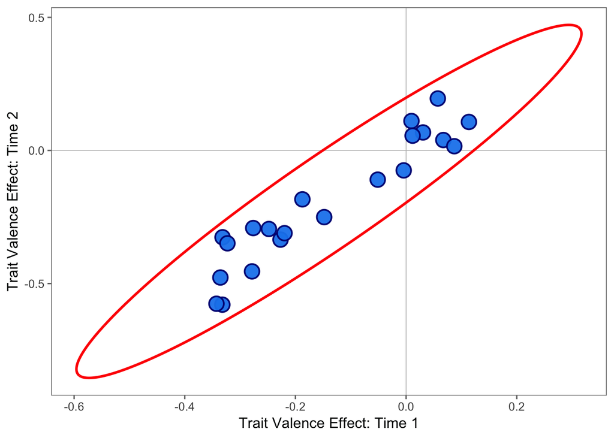

```r
ell_pop <-as.data.frame(ellipse(sigmaII_pop, centre = muII, level=0.95, npoints=1000))

temporal_plot <- ggplot(ranefboth, aes(t1_valenceE, t2_valenceE)) +
  geom_hline(yintercept = 0, size = .3, color = "gray", linetype="solid") +
  geom_vline(xintercept = 0, size = .3, color = "gray", linetype="solid") +
  geom_point(size = 5,
             shape = 21, colour = "navyblue", fill = "dodgerblue2", alpha = .95, stroke = 1) +
  xlab("Trait Valence Effect: Time 1") + ylab("Trait Valence Effect: Time 2") +
  #stat_ellipse(color = "red", lty = "solid", size = 1) +
  #geom_path(data=ell_samp, aes(x=x, y=y), size=1, linetype="longdash", color = "dodgerblue2")+
  geom_path(data=ell_pop, aes(x=x, y=y), colour='red', size = 1)+
  theme(text = element_text(size=12)) + theme_few()
temporal_plot
```

```r
# ggsave(temporal_plot, file = "Fig11_temporal_plot.pdf", height = 4, width = 4)
```

## Temporal Stability Analysis fixing correlation of trait valence effect to 1.0

This analysis aims to understand whether the correlation of the valence effect at Times 1 and 2 is essentially 1.0. To do this, we fit a new version of the model in which participant gets a person-specific valence effect that is the same for T1 and T2; because each participant has their same slope for both timepoints, there is effectively a perfect correlation between their slopes at T1 and T2

```r
logRTboth2 <- lmer(rt_log ~ t2 * valenceE +
                    (t2 + valenceE | subj),
                  data=RTexptboth)
summary(logRTboth2)
```

```
## Linear mixed model fit by REML t-tests use Satterthwaite approximations
##   to degrees of freedom [lmerMod]
## Formula: rt_log ~ t2 * valenceE + (t2 + valenceE | subj)
##    Data: RTexptboth
##
## REML criterion at convergence: 694.6
##
## Scaled residuals:
##     Min      1Q  Median      3Q     Max
## -2.3162 -0.6455 -0.1556  0.4357  4.2408
##
## Random effects:
##  Groups   Name        Variance Std.Dev. Corr
##  subj     (Intercept) 0.04136  0.2034
##           t2          0.01781  0.1334   -0.27
##           valenceE    0.04981  0.2232   -0.16  0.33
##  Residual             0.11538  0.3397
## Number of obs: 850, groups:  subj, 21
##
## Fixed effects:
##              Estimate Std. Error        df t value Pr(>|t|)
## (Intercept)   7.05987    0.04800  19.30000 147.081   <2e-16 ***
## t2           -0.06413    0.03808  21.60000  -1.684   0.1065
## valenceE     -0.14366    0.06146  27.70000  -2.338   0.0269 *
## t2:valenceE  -0.04250    0.05131 702.20000  -0.828   0.4077
## ---
## Signif. codes:  0 '***' 0.001 '**' 0.01 '*' 0.05 '.' 0.1 ' ' 1
##
## Correlation of Fixed Effects:
##             (Intr) t2     valncE
## t2          -0.357
## valenceE    -0.191  0.281
## t2:valenceE  0.078 -0.164 -0.416
```

Then, we can compare how well the new version of the model fits the data compared to the original model in which we modeled effects separately for each timepoint.

```r
## Compare model fit to original analysis
anova(logRTboth, logRTboth2)
```

```
## refitting model(s) with ML (instead of REML)
```

```
## Data: RTexptboth
## Models:
## ..1: rt_log ~ t2 * valenceE + (t2 + valenceE | subj)
## object: rt_log ~ -1 + t1 + t2 + t1:valenceE + t2:valenceE + (-1 + t1 +
## object:     t2 + t1:valenceE + t2:valenceE | subj)
##        Df    AIC    BIC  logLik deviance  Chisq Chi Df Pr(>Chisq)
## ..1    11 699.28 751.48 -338.64   677.28
## object 15 703.78 774.96 -336.89   673.78 3.4984      4     0.4781
```

## Temporal Stability: Bayesian Example

Main analysis

```r
logRTboth_bayesian <- brm(rt_log ~ -1 + t1 + t2
                  + t1:valenceE
                  + t2:valenceE +
                    (-1 + t1 + t2
                     + t1:valenceE
                     + t2:valenceE | subj),
                  data=RTexptboth, cores = 4, chains = 2, seed = 9)
summary(logRTboth_bayesian)
```

```
##  Family: gaussian
##   Links: mu = identity; sigma = identity
## Formula: rt_log ~ -1 + t1 + t2 + t1:valenceE + t2:valenceE + (-1 + t1 + t2 + t1:valenceE + t2:valenceE | subj)
##    Data: RTexptboth (Number of observations: 850)
## Samples: 2 chains, each with iter = 2000; warmup = 1000; thin = 1;
##          total post-warmup samples = 2000
##
## Group-Level Effects:
## ~subj (Number of levels: 21)
##                              Estimate Est.Error l-95% CI u-95% CI
## sd(t1)                           0.21      0.04     0.14     0.30
## sd(t2)                           0.23      0.04     0.16     0.33
## sd(t1:valenceE)                  0.18      0.06     0.09     0.31
## sd(t2:valenceE)                  0.28      0.07     0.15     0.42
## cor(t1,t2)                       0.70      0.15     0.34     0.93
## cor(t1,t1:valenceE)              0.04      0.29    -0.49     0.60
## cor(t2,t1:valenceE)              0.23      0.27    -0.34     0.69
## cor(t1,t2:valenceE)             -0.14      0.25    -0.60     0.35
## cor(t2,t2:valenceE)             -0.07      0.25    -0.54     0.43
## cor(t1:valenceE,t2:valenceE)     0.74      0.19     0.25     0.97
##                              Eff.Sample Rhat
## sd(t1)                              909 1.00
## sd(t2)                              980 1.00
## sd(t1:valenceE)                    1078 1.00
## sd(t2:valenceE)                    1216 1.00
## cor(t1,t2)                          992 1.00
## cor(t1,t1:valenceE)                1596 1.00
## cor(t2,t1:valenceE)                1689 1.00
## cor(t1,t2:valenceE)                1598 1.00
## cor(t2,t2:valenceE)                1066 1.00
## cor(t1:valenceE,t2:valenceE)        987 1.00
##
## Population-Level Effects:
##             Estimate Est.Error l-95% CI u-95% CI Eff.Sample Rhat
## t1              7.05      0.05     6.96     7.15        773 1.00
## t2              7.00      0.05     6.90     7.10        907 1.00
## t1:valenceE    -0.14      0.06    -0.25    -0.02       1514 1.00
## t2:valenceE    -0.19      0.07    -0.33    -0.05       1531 1.00
##
## Family Specific Parameters:
##       Estimate Est.Error l-95% CI u-95% CI Eff.Sample Rhat
## sigma     0.34      0.01     0.33     0.36       2000 1.00
##
## Samples were drawn using sampling(NUTS). For each parameter, Eff.Sample
## is a crude measure of effective sample size, and Rhat is the potential
## scale reduction factor on split chains (at convergence, Rhat = 1).
```

```r
# using default (uninformative) prior
# note: this model may take a few minutes to run
# settings for chains and cores can be adjusted to help with run time
```

Save random effects

```r
ranefs_both_bayes <- data.frame(ranef(logRTboth_bayesian)$subj)
colnames(ranefs_both_bayes) <- c("t1", "t2", "t1val", "t2val")
```

Analysis fixing slopes at T1 and T2 to be the same

```r
logRTboth_bayesian2 <- brm(rt_log ~ t2 * valenceE +
                    (t2 + valenceE | subj),
                  data=RTexptboth, cores = 4, chains = 2, seed = 9)
```

## Compare Bayesian model fits

```r
WAIC(logRTboth_bayesian, logRTboth_bayesian2)
```

```
##                                            WAIC    SE
## logRTboth_bayesian                       643.86 55.59
## logRTboth_bayesian2                      635.15 55.83
## logRTboth_bayesian - logRTboth_bayesian2   8.71  4.21
```

```r
LOO(logRTboth_bayesian, logRTboth_bayesian2)
```

```
##                                           LOOIC    SE
## logRTboth_bayesian                       644.99 55.64
## logRTboth_bayesian2                      635.76 55.85
## logRTboth_bayesian - logRTboth_bayesian2   9.22  4.20
```

## Correlation of Individual-Specific Raw Effects (no random effects)

This analysis computes the “raw” difference in RT to positive vs. negative words for each person at each timepoint. The T1 raw differences are then correlated with the T2 raw differences.

```r
RTexptboth_t1 <- subset(RTexptboth, t1 == 1)
RTexptboth_t1$posval <- ifelse(RTexptboth_t1$valenceE == .5, 1, 0)
RTexptboth_t1<- within(RTexptboth_t1, {numpos = ave(posval, subj, FUN = sum.na)})
RTexptboth_t1$negval <- ifelse(RTexptboth_t1$valenceE == -.5, 1, 0)
RTexptboth_t1<- within(RTexptboth_t1, {numneg = ave(negval, subj, FUN = sum.na)})

sort(RTexptboth_t1$numpos)
```

```
##   [1]  5  5  5  5  5  5  5  5  5  5  5  5  5  5  5  5  5  5  5  5  5  5  5
##  [24]  5  5  5  5  5  5  5  5  5  5  5  5  5  5  5  7  7  7  7  7  7  7  7
##  [47]  7  7  7  7  7  7  7  7  7  7  7  7  8  8  8  8  8  8  8  8  8  8  8
##  [70]  8  8  8  8  8  8  8  8  8  8  8  8  8  8  8  8  8  8  8  8  8  8  8
##  [93]  8  8  8  8  9  9  9  9  9  9  9  9  9  9  9  9 10 10 10 10 10 10 10
## [116] 10 10 10 10 10 10 10 10 10 10 10 10 11 11 11 11 11 11 11 11 11 11 11
## [139] 11 11 11 11 11 11 11 11 12 12 12 12 12 12 12 12 12 12 12 12 12 12 12
## [162] 12 12 12 12 12 12 12 12 12 12 12 12 12 12 12 12 12 12 12 12 12 12 12
## [185] 12 12 12 12 12 14 14 14 14 14 14 14 14 14 14 14 14 14 14 14 14 14 14
## [208] 14 14 14 14 14 14 14 14 14 14 14 14 14 14 14 14 16 16 16 16 16 16 16
## [231] 16 16 16 16 16 16 16 16 16 16 16 16 16 16 16 16 16 16 16 17 17 17 17
## [254] 17 17 17 17 17 17 17 17 17 17 17 17 17 17 17 17 17 17 17 17 17 17 17
## [277] 17 17 17 17 17 17 17 17 17 17 17 17 17 17 17 17 17 17 17 17 17 17 17
## [300] 17 17 17 17 17 17 17 17 17 17 17 17 17 18 18 18 18 18 18 18 18 18 18
## [323] 18 18 18 18 18 18 18 18 18 18 18 18 18 18 18 18 18 18 18 18 18 18 18
## [346] 18 18 18 18 18 18 18 18 18 18 18 18 18 18 18 18 18 18 18 18 18 18 18
## [369] 18 18 18 18 18 18 18 18 18 18 18 18 18 19 19 19 19 19 19 19 19 19 19
## [392] 19 19 19 19 19 19 19 19 19 19 19 19 19 19 19 19 20 20 20 20 20 20 20
## [415] 20 20 20 20 20 20 20 20 20 20 20 20 20 20 20 20
```

```r
sort(RTexptboth_t1$numneg)
```

```
##   [1]  1  1  1  1  1  1  1  1  1  1  1  1  1  1  1  2  2  2  2  2  2  2  2
##  [24]  2  2  2  2  2  2  2  2  2  2  2  3  3  3  3  3  3  3  3  3  3  3  3
##  [47]  3  3  3  3  3  3  3  3  3  3  3  3  3  3  3  3  3  3  3  3  3  3  3
##  [70]  3  3  3  3  3  3  3  3  3  3  3  3  3  3  3  3  3  3  3  3  3  4  4
##  [93]  4  4  4  4  4  4  4  4  4  4  4  4  4  4  4  4  4  4  4  4  5  5  5
## [116]  5  5  5  5  5  5  5  5  5  5  5  5  5  5  5  5  5  5  5  5  5  5  5
## [139]  5  5  5  5  5  5  5  5  5  5  5  5  5  5  5  5  5  5  5  5  5  5  5
## [162]  5  5  5  5  5  5  5  5  5  5  5  5  5  5  7  7  7  7  7  7  7  7  7
## [185]  7  7  7  7  7  7  7  7  7  7  7  7  7  7  7  7  7  8  8  8  8  8  8
## [208]  8  8  8  8  8  8  8  8  8  8  8  8  8  8  8  8  8  8  8  8  8  8  8
## [231]  8  8  8  8  8  8  8  8  8  8  8  8  8  8  8  8  8  8  8  8  8  8  8
## [254]  8  8  8  8  8  8  8  8  8  8  8  8  8  9  9  9  9  9  9  9  9  9  9
## [277]  9  9  9  9  9  9  9  9  9  9  9  9  9  9  9  9  9  9  9  9  9  9  9
## [300]  9  9  9 10 10 10 10 10 10 10 10 10 10 10 10 10 10 10 10 10 10 10 10
## [323] 10 10 10 10 10 10 11 11 11 11 11 11 11 11 11 11 11 11 11 11 11 11 11
## [346] 11 11 11 11 11 11 11 11 11 11 11 11 11 11 11 11 11 11 11 11 11 11 13
## [369] 13 13 13 13 13 13 13 13 13 13 13 13 13 13 13 13 13 13 13 13 13 13 13
## [392] 13 13 13 13 13 13 13 13 13 13 13 13 13 13 13 13 13 17 17 17 17 17 17
## [415] 17 17 17 17 17 17 17 17 17 17 17 17 17 17 17 17
```

```r
# there is one subject who only endorsed 1 neg item
head(arrange(RTexptboth_t1, numneg)) # subject 27
```

```
##     X subj rt_log valenceE t1 t2 posval numpos negval numneg
## 1 732   27   7.07     -0.5  1  0      0     14      1      1
## 2 736   27   6.34      0.5  1  0      1     14      0      1
## 3 737   27   6.45      0.5  1  0      1     14      0      1
## 4 738   27   6.51      0.5  1  0      1     14      0      1
## 5 739   27   6.53      0.5  1  0      1     14      0      1
## 6 740   27   6.66      0.5  1  0      1     14      0      1
```

```r
RTexptboth_t2 <- subset(RTexptboth, t2 == 1)
RTexptboth_t2$posval <- ifelse(RTexptboth_t2$valenceE == .5, 1, 0)
RTexptboth_t2<- within(RTexptboth_t2, {numpos = ave(posval, subj, FUN = sum.na)})
RTexptboth_t2$negval <- ifelse(RTexptboth_t2$valenceE == -.5, 1, 0)
RTexptboth_t2<- within(RTexptboth_t2, {numneg = ave(negval, subj, FUN = sum.na)})

sort(RTexptboth_t2$numpos)
```

```
##   [1]  4  4  4  4  4  4  4  4  4  4  4  4  4  4  4  4  4  5  5  5  5  5  5
##  [24]  5  5  5  5  5  5  5  5  5  5  5  5  5  5  5  5  5  5  5  5  5  5  5
##  [47]  5  5  5  5  5  5  5  5  5  6  6  6  6  6  6  6  6  6  6  6  6  6  6
##  [70]  7  7  7  7  7  7  7  7  7  7  7  7  7  7  7  7  7  7  7  7  7  7  7
##  [93]  7  9  9  9  9  9  9  9  9  9  9  9  9  9  9  9  9  9  9  9  9  9  9
## [116]  9  9  9  9  9  9  9 10 10 10 10 10 10 10 10 10 10 10 10 10 10 10 10
## [139] 10 10 10 10 10 10 10 10 10 10 10 10 10 10 10 10 10 10 10 10 10 10 10
## [162] 10 10 10 10 10 10 11 11 11 11 11 11 11 11 11 11 11 11 11 11 11 11 11
## [185] 11 11 11 11 11 11 11 12 12 12 12 12 12 12 12 12 12 12 12 12 12 12 12
## [208] 12 12 13 13 13 13 13 13 13 13 13 13 13 13 13 13 13 13 14 14 14 14 14
## [231] 14 14 14 14 14 14 14 14 14 14 14 14 14 14 14 14 14 16 16 16 16 16 16
## [254] 16 16 16 16 16 16 16 16 16 16 16 16 16 16 16 16 16 16 16 16 16 16 16
## [277] 16 16 16 16 16 16 16 16 16 17 17 17 17 17 17 17 17 17 17 17 17 17 17
## [300] 17 17 17 17 17 17 17 17 17 17 17 17 17 17 17 17 17 17 17 17 17 17 17
## [323] 17 17 17 17 17 17 17 17 17 17 17 17 17 17 17 17 17 17 17 17 17 17 17
## [346] 17 17 17 17 17 17 17 18 18 18 18 18 18 18 18 18 18 18 18 18 18 18 18
## [369] 18 18 18 18 18 18 18 18 18 18 18 18 18 18 18 18 18 18 18 18 18 18 18
## [392] 18 18 18 18 18 18 18 19 19 19 19 19 19 19 19 19 19 19 19 19 19 19 19
## [415] 19 19 19 19 19 19
```

```r
sort(RTexptboth_t2$numneg)
```

```
##   [1]  2  2  2  2  2  2  2  2  2  2  2  2  2  2  2  2  2  2  2  2  2  2  2
##  [24]  2  2  2  2  2  2  2  2  3  3  3  3  3  3  3  3  3  3  3  3  3  3  3
##  [47]  3  3  3  3  3  3  3  3  3  3  3  3  3  3  3  3  3  3  3  3  3  3  3
##  [70]  3  3  3  3  3  3  3  3  3  3  3  3  3  3  3  3  3  3  3  3  3  3  3
##  [93]  3  3  3  3  3  3  3  3  3  3  3  3  3  3  3  3  3  3  3  3  3  3  3
## [116]  3  3  3  3  3  3  3  3  3  3  3  3  4  4  4  4  4  4  4  4  4  4  4
## [139]  4  4  4  4  4  4  4  4  4  4  6  6  6  6  6  6  6  6  6  6  6  6  6
## [162]  6  6  6  6  6  8  8  8  8  8  8  8  8  8  8  8  8  8  8  8  8  8  8
## [185]  8  8  8  8  8  8  8  8  8  8  8  8  8  8  8  8  8  8  8  8  8  8  8
## [208]  8  8  8  8  8  8  8  8  8  8  8  8  8  8  8  8  8  8  8  8  8  9  9
## [231]  9  9  9  9  9  9  9  9  9  9  9  9  9  9  9  9  9  9  9  9  9  9  9
## [254]  9  9  9  9  9  9  9  9  9  9  9  9  9  9  9  9  9  9  9 11 11 11 11
## [277] 11 11 11 11 11 11 11 11 11 11 11 11 11 11 11 11 11 13 13 13 13 13 13
## [300] 13 13 13 13 13 13 13 13 13 13 13 13 13 13 13 13 13 13 13 13 13 13 13
## [323] 13 13 13 13 13 13 13 13 13 13 13 13 13 13 13 13 13 13 13 13 13 13 13
## [346] 13 13 13 13 13 13 13 14 14 14 14 14 14 14 14 14 14 14 14 14 14 14 14
## [369] 14 14 14 14 14 14 14 14 15 15 15 15 15 15 15 15 15 15 15 15 15 15 15
## [392] 15 15 15 15 15 17 17 17 17 17 17 17 17 17 17 17 17 17 17 17 17 17 17
## [415] 17 17 17 17 17 17
```

```r
# all subjects have at least two observations per valence group


#RTexptboth <- dplyr::select(RTexptboth, -X)
#RTexptboth  <- row.names()
```

Compute raw RT difference for T1

```r
##### T1 raw values
t_ids <- as.vector(unique(subset(RTexptboth, subj != 27)$subj))
t1_diff <- data.frame(subj = t_ids, t1_diff = NA)
RTexptboth$valenceEfac <- ifelse(RTexptboth$valenceE == -.5, "n", "p")

for(i in t_ids){
  data_i <- subset(RTexptboth, subj == i & t1 == 1)
  rts <- split(data_i, data_i$valenceEfac)
  t <- t.test(rts$n[, "rt_log"], rts$p[, "rt_log"])
  t1_diff$t1_diff[t1_diff$subj == i] <- t$estimat[2]-t$estimat[1]
}
t1_diff_i <- arrange(t1_diff, subj)
```

```r
##### T2 raw values
t2_diff <- data.frame(subj = t_ids, t2_diff = NA)

for(i in t_ids){
  data_i <- subset(RTexptboth, subj == i & t2 == 1)
  rts <- split(data_i, data_i$valenceEfac)
  t <- t.test(rts$n[, "rt_log"], rts$p[, "rt_log"])
  t2_diff$t2_diff[t2_diff$subj == i] <- t$estimat[2]-t$estimat[1]
}
t2_diff_i <- arrange(t2_diff, subj)
```

Merge and correlate T1 and T2 raw values

```r
both_merge <- merge(t1_diff_i, t2_diff_i, by = "subj")
cor.test(both_merge$t1_diff, both_merge$t2_diff) # .80
```

```
##
##  Pearson's product-moment correlation
##
## data:  both_merge$t1_diff and both_merge$t2_diff
## t = 5.5728, df = 18, p-value = 2.735e-05
## alternative hypothesis: true correlation is not equal to 0
## 95 percent confidence interval:
##  0.5450459 0.9157484
## sample estimates:
##       cor
## 0.7956585
```

## Temporal Stability Analysis controlling for regulatory focus induction condition

This analysis accounts for a between-subjects regulatory focus induction administered between the Time 1 and Time 2 valence tasks.

Read in dataframe that contains information about condition (available from the authors by request).

```r
manip <- read.csv("temporalstability_rfcondition.csv")
```

Merge datasets to add information about condition

```r
RTexptboth2 <- merge(RTexptboth, manip, by = "subj")
```

Temporal stability analysis with main effect of induction and induction x valence interaction at Time 2.

```r
logRTboth_manip <- lmer(rt_log ~ -1 + t1 + t2 +
                          t1:valenceE +
                          t2:valenceE +
                          t2:rfmanip +
                          t2:valenceE:rfmanip +
                          (-1 + t1 + t2 +
                             t1:valenceE +
                             t2:valenceE | subj),
                   data=RTexptboth2)
summary(logRTboth_manip)
```

```
## Linear mixed model fit by REML t-tests use Satterthwaite approximations
##   to degrees of freedom [lmerMod]
## Formula: rt_log ~ -1 + t1 + t2 + t1:valenceE + t2:valenceE + t2:rfmanip +
##     t2:valenceE:rfmanip + (-1 + t1 + t2 + t1:valenceE + t2:valenceE |
##     subj)
##    Data: RTexptboth2
##
## REML criterion at convergence: 691
##
## Scaled residuals:
##     Min      1Q  Median      3Q     Max
## -2.3781 -0.6640 -0.1499  0.4637  4.2448
##
## Random effects:
##  Groups   Name        Variance Std.Dev. Corr
##  subj     t1          0.03719  0.1928
##           t2          0.04342  0.2084    0.85
##           t1:valenceE 0.03463  0.1861    0.03  0.23
##           t2:valenceE 0.07530  0.2744   -0.23 -0.06  0.96
##  Residual             0.11476  0.3388
## Number of obs: 850, groups:  subj, 21
##
## Fixed effects:
##                     Estimate Std. Error       df t value Pr(>|t|)
## t1                   7.05658    0.04573 18.65000 154.310  < 2e-16 ***
## t2                   7.03360    0.05099 20.97000 137.948  < 2e-16 ***
## t1:valenceE         -0.14562    0.05482 21.96000  -2.656  0.01444 *
## t2:valenceE         -0.22485    0.07398 19.59000  -3.039  0.00658 **
## t2:rfmanip           0.14865    0.06923 18.29000   2.147  0.04542 *
## t2:valenceE:rfmanip -0.18862    0.11528 32.64000  -1.636  0.11140
## ---
## Signif. codes:  0 '***' 0.001 '**' 0.01 '*' 0.05 '.' 0.1 ' ' 1
##
## Correlation of Fixed Effects:
##             t1     t2     t1:vlE t2:vlE t2:rfm
## t2           0.714
## t1:valenceE -0.065  0.127
## t2:valenceE -0.190 -0.095  0.610
## t2:rfmanip   0.009  0.267 -0.035 -0.024
## t2:vlncE:rf -0.037 -0.021  0.040  0.292 -0.121
```